# Supplementary Materials: Efficacy of psychosocial interventions for Autism Spectrum Disorder: an umbrella review.

Gosling CJ, Cartigny A, Mellier BC, Solanes A, Radua J & Delorme R

30/05/2022

# Preparation of the datasets

In this section, we aggregate the dataframe at the meta-analysis level to obtain the characteristics of participants (e.g., mean age, % male, etc.) and interventions (e.g., mean intensity and frequency) for each meta-analysis included in the review

## Dataset 1

This dataset is used in S1 and S2.B

```r
# identify multiple comparisons group as a unique group
df_raw$year <- gsub("b", "", df_raw$year)

df_raw$author_year <- with(df_raw, paste0(df_raw$author, " (", df_raw$year, ")"))
# calculate the sample size of studies with multiple groups (sum) or outcomes (max)
df_N_CCT <- data.table::setDT(df_raw)[, .(x = sum(N_tot)), by =.(First_author_meta, Year_meta, Intervention_general, Intervention_precise, author, year, Outcome_general, multiple_es, id_row)][, .(N_cor = max(x)), by=.(First_author_meta, Year_meta, Intervention_general, Intervention_precise, author, year, Outcome_general)]

# reinsert corrected sample size in the initial dataset
df1 <- dplyr::left_join(df_raw, df_N_CCT, by = c("First_author_meta", "Year_meta", "Intervention_general", "Intervention_precise", "author", "year", "Outcome_general"))

# aggregate dataset at the outcome level
df_agg_outcome <- df1[, lapply(.SD, function(x) weighted.mean(x, N_cor, na.rm = TRUE)),
              by = c("First_author_meta", "Year_meta", "Intervention_general", "Intervention_precise", "author", "year", "Outcome_general"),
              .SDcols = c(# participants
                          "MeanAge", "MeanIQ", "PercMale",
                          # intervention - length
                          "LengthWeek", "DurationMonth",
                          # intervention -implementer
                          "parent_imp", "prof_imp",
                          # intervention -setting
                          "sett_home", "sett_clin", "sett_class",
                          # RoB
                          "Design_num", "RoB_BlindOut_num", "low_RoB_num",
                          # outcome
                          "Outcome_test", "Outcome_questionnaire", "Outcome_observation",
                          "Active_controls")]

df2 <- dplyr::left_join(data.frame(df_agg_outcome), data.frame(df_N_CCT))

# aggregate dataset at the meta-analysis level
df_agg_meta <- data.table::setDT(df2)[, lapply(.SD, function(x)  weighted.mean(x, N_cor, na.rm = TRUE)),
                by = c("First_author_meta", "Year_meta", "Intervention_general", "Intervention_precise",
                       "Outcome_general"),
                .SDcols =  c(# participants
                            "MeanAge", "MeanIQ", "PercMale",
                            # intervention - length
                            "LengthWeek", "DurationMonth",
                            # intervention -implementer
                            "parent_imp", "prof_imp",
                            # intervention -setting
                            "sett_home", "sett_clin", "sett_class",
                            # RoB
                            "Design_num", "RoB_BlindOut_num", "low_RoB_num",
                            # outcome
                            "Outcome_test", "Outcome_questionnaire", "Outcome_observation",
                            "Active_controls")]

# create some new variables to facilitate data presentation
df_agg_meta$factor <- with(df_agg_meta, paste0(First_author_meta, "_", Year_meta, "_", Intervention_precise, "_", Outcome_general))

df_agg_meta$Paper <- with(df_agg_meta, paste0(First_author_meta, " (", Year_meta, ")"))

df_agg_meta$LengthWeek_round <- round(df_agg_meta$LengthWeek)
df_agg_meta$Intensity <- with(df_agg_meta,
      ifelse(LengthWeek < 2, "< 2 h/wk",
        ifelse(LengthWeek < 5, "2-4 h/wk",
          ifelse(LengthWeek < 10, "5-9 h/wk",
           ifelse(LengthWeek < 20, "10-19 h/wk",
            ifelse(LengthWeek >= 20, ">= 20h/wk", NA_real_))))))

df_agg_meta$Age <- with(df_agg_meta,
      ifelse(MeanAge < 6, "< 6 yo",
        ifelse(MeanAge < 13, "6-12 yo",
          ifelse(MeanAge < 20, "13-19 yo",
            ifelse(MeanAge >= 20, ">= 20 yo", NA_real_)))))

df_agg_meta$IQ <- with(df_agg_meta,
      ifelse(MeanIQ < 70, "Low (< 70)",
        ifelse(MeanIQ < 80, "Limit (70-79)",
          ifelse(MeanIQ < 120, "Average (80-119)",
            ifelse(MeanIQ < 130, "High (120-129)",
              ifelse(MeanIQ >= 130, "Very high (130+)",
                     NA_real_))))))

df_agg_meta$Duration <- with(df_agg_meta,
      ifelse(DurationMonth < 2, "< 2 months",
        ifelse(DurationMonth <= 6, "2-6 months",
        ifelse(DurationMonth <= 12, "7-12 months",
          ifelse(DurationMonth > 12, "> 12 months",
                 NA_real_)))))

df_agg_meta <- dplyr::left_join(df_agg_meta, df_amstar)

# identify mixed age groups in meta-analyses
mixed_df = data.frame(factor = rep(NA, length(unique(df_raw$factor))), min_age = rep(NA, length(unique(df_raw$factor))), max_age = rep(NA, length(unique(df_raw$factor))), diff = rep(NA, length(unique(df_raw$factor))))
row = 1
for (fact in unique(df_raw$factor)) {
  x_i = df_raw[df_raw$factor == fact, ]
  mixed_df$factor[row] = fact
  mixed_df$min_age[row] = min(x_i$MeanAge, na.rm = TRUE)
  mixed_df$max_age[row] = max(x_i$MeanAge, na.rm = TRUE)
  mixed_df$diff[row] = max(x_i$MeanAge, na.rm = TRUE) - min(x_i$MeanAge, na.rm = TRUE)
  row = row + 1
}

df_agg_meta <- dplyr::left_join(df_agg_meta, mixed_df)
df_agg_meta$Age_bounds = paste0("[", round(df_agg_meta$min_age, 1), " - ", round(df_agg_meta$max_age, 1), "]")
```

This section is dedicated to identify the most recent and rigorous meta-analysis for each combination of intervention and outcome

```r
inter_ok = c("EIBI", "DEV", "NDBI", "SSG", "TECH", "PMI", "TEACCH", "CBT")
outcome_ok = c("Overall ASD symptoms", "Social communication",
               "Restricted repetitive behaviors", "Adaptive behaviors", "Cognition(IQ)",
               "Language(Expressive)", "Language(Receptive)", "Disruptive behaviors")

df_agg_meta$IN_meta = 0
df_agg_meta$Year_meta_num = as.numeric(gsub("a|b", "", df_agg_meta$Year_meta))
df_agg_meta$unique_meta = paste0(df_agg_meta$Intervention_precise, "_", df_agg_meta$Outcome_general)
df_agg_meta$row_id_meta = 1:nrow(df_agg_meta)

for (uniq in unique(df_agg_meta$unique_meta)) {
  df_uniq = df_agg_meta[df_agg_meta$unique_meta == uniq ,]

  if (unique(df_uniq$Intervention_precise) %in% inter_ok) {
    if(nrow(df_uniq) > 0) {
      for (age in unique(df_uniq$Age)) {
        # subset for a given age group
        df_uniq_age = df_uniq[df_uniq$Age == age, ]
        # select most recent
        if (any(df_uniq_age$Year_meta_num >= 2016) & any(df_uniq_age$Year_meta_num < 2016)) {
          df_uniq_age = df_uniq_age[df_uniq_age$Year_meta >= 2016, ]
        }
        # select highest amstar score
        row_meta = df_uniq_age[which(df_uniq_age$amstar == max(df_uniq_age$amstar)), ]$row_id_meta

        if (length(unique(df_agg_meta[df_agg_meta$row_id_meta %in% row_meta, ]$factor)) > 1) {
          df_agg_meta[df_agg_meta$row_id_meta %in% row_meta &
                        df_agg_meta$Year_meta_num == max(df_agg_meta$Year_meta_num), ]$IN_meta = 1
          print(paste("AMSTAR equality: ", unique(df_agg_meta[df_agg_meta$row_id_meta %in% row_meta, ]$factor)))
        } else {
          df_agg_meta[df_agg_meta$row_id_meta %in% row_meta, ]$IN_meta = 1
        }
      }
    }
  }
}
```

```
## [1] "AMSTAR equality:  Reichow_2018_EIBI_Cognition(IQ)"
## [2] "AMSTAR equality:  Rodgers_2021_EIBI_Cognition(IQ)"
## [1] "AMSTAR equality:  Reichow_2018_EIBI_Adaptive behaviors"
## [2] "AMSTAR equality:  Rodgers_2021_EIBI_Adaptive behaviors"
```

```r
# exclude additional outcomes from main meta analyses
df_agg_meta$IN_meta = ifelse(!(df_agg_meta$Outcome_general %in% outcome_ok), 0, df_agg_meta$IN_meta)
```

This section is dedicated to identify a unique occurrence of each individual trial

```r
IN_factor = df_agg_meta[which(df_agg_meta$IN_meta == 1), ]$factor
df_raw$Year_meta_num = as.numeric(gsub("a|b", "", df_raw$Year_meta))
df_raw$IN_trial = 0

for (aut in unique(df_raw$author_year)) {
  df_uniq = df_raw[df_raw$author_year == aut, ]
  for (out in unique(df_uniq$Outcome_general)) {
    df_uniq_out = df_uniq[which(df_uniq$Outcome_general == out), ]
      if (length(unique(df_uniq_out$factor)) > 1) {
          row_trial = df_uniq_out[which(df_uniq_out$amstar == max(df_uniq_out$amstar)), ]$row_id
          if (length(unique(with(df_uniq_out[df_uniq_out$row_id %in% row_trial, ],
                                 paste(First_author_meta, Year_meta)))) > 1) {
            df_raw[which(df_raw$row_id %in% row_trial &
                           df_raw$Year_meta == max(df_uniq_out$Year_meta_num)), ]$IN_trial = 1
          } else {
            df_raw[df_raw$row_id %in% row_trial, ]$IN_trial = 1
          }
      } else {
        df_raw[which(df_raw$row_id %in% df_uniq_out$row_id), ]$IN_trial = 1
      }
  }
}

df_raw$included_trial = df_raw$IN_trial
```

## Dataset 2

```r
# subset dataframe to RCTs with low risk of bias regarding blinding of outcome assessors
df_raw_S1 <- subset(df_raw, rob == "low")

# calculate the sample size of studies with multiple groups (sum) or outcomes (max)
df_N_CCT_S1 <- data.table::setDT(df_raw_S1)[, .(x = sum(N_tot)), by =.(First_author_meta, Year_meta, Intervention_general, Intervention_precise, author, year, Outcome_general, multiple_es, id_row)][, .(N_cor = max(x)), by=.(First_author_meta, Year_meta, Intervention_general, Intervention_precise, author, year, Outcome_general)]

# reinsert corrected sample size in the initial dataset
df1_S1 <- dplyr::left_join(df_raw_S1, df_N_CCT_S1,
                           by = c("First_author_meta", "Year_meta", "Intervention_general",
                                  "Intervention_precise",
                                  "author", "year", "Outcome_general"))

# aggregate dataset at the outcome level
df_agg_outcome_S1 <- df1_S1[, lapply(.SD, function(x) weighted.mean(x, N_cor, na.rm = TRUE)),
              by = c("First_author_meta", "Year_meta", "Intervention_general", "Intervention_precise",
                     "author", "year", "Outcome_general"),
              .SDcols = c(# participants
                          "MeanAge", "MeanIQ", "PercMale",
                          # intervention - length
                          "LengthWeek", "DurationMonth",
                          # intervention -implementer
                          "parent_imp", "prof_imp",
                          # intervention -setting
                          "sett_home", "sett_clin", "sett_class",
                          # RoB
                          "Design_num", "RoB_BlindOut_num", "low_RoB_num",
                          # outcome
                          "Outcome_test", "Outcome_questionnaire", "Outcome_observation",
                          "Active_controls")]

df2_S1 <- dplyr::left_join(data.frame(df_agg_outcome_S1), data.frame(df_N_CCT_S1))

# aggregate dataset at the meta-analysis level
df_agg_meta_S1 <- data.table::setDT(df2_S1)[, lapply(.SD, function(x)  weighted.mean(x, N_cor, na.rm = TRUE)),
                by = c("First_author_meta", "Year_meta", "Intervention_general", "Intervention_precise",
                       "Outcome_general"),
                .SDcols =  c(# participants
                            "MeanAge", "MeanIQ", "PercMale",
                            # intervention - length
                            "LengthWeek", "DurationMonth",
                            # intervention -implementer
                            "parent_imp", "prof_imp",
                            # intervention -setting
                            "sett_home", "sett_clin", "sett_class",
                            # RoB
                            "Design_num", "RoB_BlindOut_num", "low_RoB_num",
                            # outcome
                            "Outcome_test", "Outcome_questionnaire", "Outcome_observation",
                            "Active_controls")]

# create some new variables to facilitate data presentation
df_agg_meta_S1$factor <- with(df_agg_meta_S1, paste0(First_author_meta, "_", Year_meta, "_", Intervention_precise, "_", Outcome_general))

df_agg_meta_S1$Paper <- with(df_agg_meta_S1, paste0(First_author_meta, " (", Year_meta, ")"))

df_agg_meta_S1$LengthWeek_round <- round(df_agg_meta_S1$LengthWeek)
df_agg_meta_S1$Intensity <- with(df_agg_meta_S1,
      ifelse(LengthWeek < 2, "< 2 h/wk",
        ifelse(LengthWeek < 5, "2-4 h/wk",
          ifelse(LengthWeek < 10, "5-9 h/wk",
           ifelse(LengthWeek < 20, "10-19 h/wk",
            ifelse(LengthWeek >= 20, ">= 20h/wk", NA_real_))))))

df_agg_meta_S1$Age <- with(df_agg_meta_S1,
      ifelse(MeanAge < 6, "< 6 yo",
        ifelse(MeanAge < 13, "6-12 yo",
          ifelse(MeanAge < 20, "13-19 yo",
            ifelse(MeanAge >= 20, ">= 20 yo", NA_real_)))))

df_agg_meta_S1$IQ <- with(df_agg_meta_S1,
      ifelse(MeanIQ < 70, "Low (< 70)",
        ifelse(MeanIQ < 80, "Limit (70-79)",
          ifelse(MeanIQ < 120, "Average (80-119)",
            ifelse(MeanIQ < 130, "High (120-129)",
              ifelse(MeanIQ >= 130, "Very high (130+)",
                     NA_real_))))))

df_agg_meta_S1$Duration <- with(df_agg_meta_S1,
      ifelse(DurationMonth < 2, "< 2 months",
        ifelse(DurationMonth <= 6, "2-6 months",
        ifelse(DurationMonth <= 12, "7-12 months",
          ifelse(DurationMonth > 12, "> 12 months",
                 NA_real_)))))

# identify mixed age groups in meta-analyses
mixed_df_S1 = data.frame(factor = rep(NA, length(unique(df_raw_S1$factor))), min_age = rep(NA, length(unique(df_raw_S1$factor))), max_age = rep(NA, length(unique(df_raw_S1$factor))), diff = rep(NA, length(unique(df_raw_S1$factor))))
row = 1
for (fact in unique(df_raw_S1$factor)) {
  x_i = df_raw_S1[df_raw_S1$factor == fact, ]
  mixed_df_S1$factor[row] = fact
  mixed_df_S1$min_age[row] = min(x_i$MeanAge, na.rm = TRUE)
  mixed_df_S1$max_age[row] = max(x_i$MeanAge, na.rm = TRUE)
  mixed_df_S1$diff[row] = max(x_i$MeanAge, na.rm = TRUE) - min(x_i$MeanAge, na.rm = TRUE)
  row = row + 1
}

df_agg_meta_S1 <- dplyr::left_join(df_agg_meta_S1, mixed_df_S1)
df_agg_meta_S1$Age_bounds = paste0("[", round(df_agg_meta_S1$min_age, 1), " - ", round(df_agg_meta_S1$max_age, 1), "]")
```

This dataset is used in S2.C

```r
df_raw_S3_t <- subset(df_raw, IN_trial == 1)
Interventions <- stringr::str_split_fixed(df_raw_S3_t$Intervention_all, ' / ', 3)
df_raw_S3_t$intervention1 <- ifelse(Interventions[, 1] == "",
                                   NA, Interventions[, 1])
df_raw_S3_t$intervention2 <- ifelse(Interventions[, 2] == "",
                                   NA, Interventions[, 2])
df_raw_S3_t$intervention3 <- ifelse(Interventions[, 3] == "",
                                   NA, Interventions[, 3])

df_raw_S3 = df_raw_S3_t %>%
  tidyr::pivot_longer(cols = c(intervention1, intervention2, intervention3),
               names_to = "intervention_rank",
               values_to = "Intervention_long")
df_raw_S3 = subset(df_raw_S3, !is.na(Intervention_long))

df_raw_S3$Age <- with(df_raw_S3,
      ifelse(MeanAge < 6, "< 6 yo",
        ifelse(MeanAge < 13, "6-12 yo",
          ifelse(MeanAge < 20, "13-19 yo",
            ifelse(MeanAge >= 20, ">= 20 yo", NA_real_)))))

df_raw_S3$factor <- paste0(df_raw_S3$Intervention_long, "_",
                          df_raw_S3$Outcome_general, "_",
                          df_raw_S3$Age)



# calculate the sample size of studies with multiple groups (sum) or outcomes (max)
df_N_CCT_S3 <- data.table::setDT(df_raw_S3)[, .(x = sum(N_tot)), by =.(Intervention_long, Age, Outcome_general, author, year, multiple_es, id_row)][, .(N_cor = max(x)), by=.(Intervention_long, Age, Outcome_general, author, year)]

# reinsert corrected sample size in the initial dataset
df1_S3 <- dplyr::left_join(df_raw_S3, df_N_CCT_S3,
                           by = c("Intervention_long",
                                  "Age", "Outcome_general",
                                  "author", "year"))

# aggregate dataset at the outcome level
df_agg_outcome_S3 <- df1_S3[, lapply(.SD, function(x) weighted.mean(x, N_cor, na.rm = TRUE)),
              by = c("Intervention_long", "Age", "Outcome_general",
                     "author", "year"),
              .SDcols = c(# participants
                          "MeanAge", "MeanIQ", "PercMale",
                          # intervention - length
                          "LengthWeek", "DurationMonth",
                          # intervention -implementer
                          "parent_imp", "prof_imp",
                          # intervention -setting
                          "sett_home", "sett_clin", "sett_class",
                          # RoB
                          "Design_num", "RoB_BlindOut_num", "low_RoB_num",
                          # outcome
                          "Outcome_test", "Outcome_questionnaire", "Outcome_observation",
                          "Active_controls")]

df2_S3 <- dplyr::left_join(data.frame(df_agg_outcome_S3), data.frame(df_N_CCT_S3))

# aggregate dataset at the meta-analysis level
df_agg_meta_S3 <- data.table::setDT(df2_S3)[, lapply(.SD, function(x)  weighted.mean(x, N_cor, na.rm = TRUE)),
              by = c("Intervention_long", "Age", "Outcome_general"),
                .SDcols =  c(# participants
                            "MeanAge", "MeanIQ", "PercMale",
                            # intervention - length
                            "LengthWeek", "DurationMonth",
                            # intervention -implementer
                            "parent_imp", "prof_imp",
                            # intervention -setting
                            "sett_home", "sett_clin", "sett_class",
                            # RoB
                            "Design_num", "RoB_BlindOut_num", "low_RoB_num",
                            # outcome
                            "Outcome_test", "Outcome_questionnaire", "Outcome_observation",
                            "Active_controls")]

# create some new variables to facilitate data presentation
df_agg_meta_S3$factor <- with(df_agg_meta_S3, paste0(Intervention_long, "_", Outcome_general, "_", Age))

df_agg_meta_S3$LengthWeek_round <- round(df_agg_meta_S3$LengthWeek)
df_agg_meta_S3$Intensity <- with(df_agg_meta_S3,
      ifelse(LengthWeek < 2, "< 2 h/wk",
        ifelse(LengthWeek < 5, "2-4 h/wk",
          ifelse(LengthWeek < 10, "5-9 h/wk",
           ifelse(LengthWeek < 20, "10-19 h/wk",
            ifelse(LengthWeek >= 20, ">= 20h/wk", NA_real_))))))

df_agg_meta_S3$IQ <- with(df_agg_meta_S3,
      ifelse(MeanIQ < 70, "Low (< 70)",
        ifelse(MeanIQ < 80, "Limit (70-79)",
          ifelse(MeanIQ < 120, "Average (80-119)",
            ifelse(MeanIQ < 130, "High (120-129)",
              ifelse(MeanIQ >= 130, "Very high (130+)",
                     NA_real_))))))

df_agg_meta_S3$Duration <- with(df_agg_meta_S3,
      ifelse(DurationMonth < 2, "< 2 months",
        ifelse(DurationMonth <= 6, "2-6 months",
        ifelse(DurationMonth <= 12, "7-12 months",
          ifelse(DurationMonth > 12, "> 12 months",
                 NA_real_)))))

# identify mixed age groups in meta-analyses
mixed_df_S3 = data.frame(factor = rep(NA, length(unique(df_raw_S3$factor))), min_age = rep(NA, length(unique(df_raw_S3$factor))), max_age = rep(NA, length(unique(df_raw_S3$factor))), diff = rep(NA, length(unique(df_raw_S3$factor))))
row = 1
for (fact in unique(df_raw_S3$factor)) {
  x_i = df_raw_S3[df_raw_S3$factor == fact, ]
  mixed_df_S3$factor[row] = fact
  mixed_df_S3$min_age[row] = min(x_i$MeanAge, na.rm = TRUE)
  mixed_df_S3$max_age[row] = max(x_i$MeanAge, na.rm = TRUE)
  mixed_df_S3$diff[row] = max(x_i$MeanAge, na.rm = TRUE) - min(x_i$MeanAge, na.rm = TRUE)
  row = row + 1
}

df_agg_meta_S3 <- dplyr::left_join(df_agg_meta_S3, mixed_df_S3)
df_agg_meta_S3$Age_bounds = paste0("[", round(df_agg_meta_S3$min_age, 1), " - ", round(df_agg_meta_S3$max_age, 1), "]")
```

# S1. Main analysis

## A. Data analysis

We perform the umbrella review with assessment of the credibility of evidence using algorithmic criteria

```r
df_raw$shared_controls <- NA

umb.main <- metaumbrella::umbrella(df_raw, mult.level = TRUE, method.var = "REML", r = 0.8, verbose = FALSE)
res.transit <- metaumbrella::add.evidence(umb.main,
    criteria = "Personalized",
    class_I = c(total_n = 500, p_value = 1e-3, I2 = 50,
                egger_p = .05, pi = "notnull",
                rob = 75, amstar = 4.99),
    class_II = c(total_n = 350, p_value = 1e-3,
                largest_CI = "notnull",
                rob = 50, amstar = 3.99),
    class_III = c(total_n = 200, p_value = 1e-3),
    class_IV = c(p_value = 5e-2), verbose = FALSE)

res <- metaumbrella::summary.umbrella(res.transit)
res <- gen_id(res$Factor, res)
```

We perform some manipulation on the resulting dataset to facilitate data presentation

```r
# merge datasets
res$factor <- with(res, paste0(Author, "_", Year, "_", Intervention, "_", Outcome))
res.main <- dplyr::left_join(res, df_agg_meta)

# estimate the STANDARD ERROR of the pooled ES
ci_lo_transit <- ci_up_transit <- CI_up <- CI_lo <- NA
for (i in 1:nrow(res.main)) {
  ci_lo_transit[i] <- gsub(",.*", "", res.main$value_CI[i])
  ci_up_transit[i] <- gsub(".*, ", "", res.main$value_CI[i])
  CI_lo[i] <- gsub("\\[", "", ci_lo_transit[i])
  CI_up[i] <- gsub("]", "", ci_up_transit[i])
}
CI_lo <- as.numeric(as.character(CI_lo))
CI_up <- as.numeric(as.character(CI_up))
res.main$se <- (CI_up - CI_lo) / 3.92

# Create/recode some variables
res.main$total_n <- round(res.main$total_n)
res.main$Class <- ifelse(res.main$Class == "V", "ns", as.character(res.main$Class))
res.main$Sample_size_studies <- with(res.main, paste0(total_n, " (", n_studies, ")"))
res.main$Effect_size <- paste0("SMD = ", res.main$value, " [", CI_lo, ", ", CI_up, "]")
res.main$Risk_of_bias <- with(res.main, ifelse(rob < 50, "High",
        ifelse(rob < 75, "Med.", ifelse(rob >= 75, "Low", NA_real_))))
res.main$Active_controls <- paste0(round(res.main$Active_controls), "%")

# Identify main characteristics (setting, outcome type, therapy implementer)
res.main = main_characteristics(res.main)
```

```r
df_n_out_tot <- do.call(rbind, lapply(split(res.main, res.main$Intervention), n_out))
df_n_out_sub <- do.call(rbind, lapply(split(subset(res.main, IN_meta == 1), subset(res.main, IN_meta == 1)$Intervention), n_out))

df_numb_out_tot <- do.call(rbind, lapply(split(res.main, res.main$Intervention), numb_out_miss))
df_numb_out_sub <- do.call(rbind, lapply(split(subset(res.main, IN_meta == 1), subset(res.main, IN_meta == 1)$Intervention), numb_out_miss))
```

## B. Description of the MA

We provide a general description of the meta-analyses found in the review

```r
############################################
# General description of the meta-analyses #
############################################
paste0(
## Number of eligible articles ---
  paste0("The number of eligible articles identified by our systematic review is equal to: ", length(unique(res.main$Paper)), ". "),

  ## Number of meta-analyses and CCTs ---
  paste0("In these articles, a total of ",
         length(unique(res.main$factor)),
         " meta-analyses are reported, including ",
         nrow(unique(cbind(df_raw$author, df_raw$year))) - 1 # lopata/rodgers
         + length(unique(subset(df_raw, multiple_es == "groups")$author)),
         " unique CCTs and ", nrow(df_raw), " effect size estimates. "),

  ## Number of intervention types and outcomes ---
  paste0("The meta-analyses were systematically categorized into 8 intervention types [EIBI (n = ",
         sum(apply(df_n_out_tot, 1, sum)[which(grepl("EIBI", names(apply(df_n_out_tot, 1, sum)), fixed = TRUE))]),
         "), NDBI (n = ",
         sum(apply(df_n_out_tot, 1, sum)[which(grepl("NDBI", names(apply(df_n_out_tot, 1, sum)), fixed = TRUE))]),
         "), PMI (n = ",
         # - 1 for tech pmi
         sum(apply(df_n_out_tot, 1, sum)[which(grepl("PMI", names(apply(df_n_out_tot, 1, sum)), fixed = TRUE))]) - 1,
          "), SSG (n = ",
         # - 1 for tech ssg
         sum(apply(df_n_out_tot, 1, sum)[which(grepl("SSG", names(apply(df_n_out_tot, 1, sum)), fixed = TRUE))]) - 1,
          "), TECH (n = ",
         sum(apply(df_n_out_tot, 1, sum)[which(grepl("TECH", names(apply(df_n_out_tot, 1, sum)), fixed = TRUE))]),
          "), TEACCH (n = ",
         sum(apply(df_n_out_tot, 1, sum)[which(grepl("TEACCH", names(apply(df_n_out_tot, 1, sum)), fixed = TRUE))]),
         "), DEV (n = ",
         sum(apply(df_n_out_tot, 1, sum)[which(grepl("DEV", names(apply(df_n_out_tot, 1, sum)), fixed = TRUE))]),
         "), CBT (n = ",
         sum(apply(df_n_out_tot, 1, sum)[which(grepl("CBT", names(apply(df_n_out_tot, 1, sum)), fixed = TRUE))]),
         ")] and 8 outcomes [social communication (n = ",
         sum(df_n_out_tot$SC),
         "), language (composite: n = ",
         sum(df_n_out_tot$LT),
         "; receptive: n = ",
         sum(df_n_out_tot$LR),
         "; expressive: n = ",
         sum(df_n_out_tot$LE),
          "), IQ (global IQ: n = ",
         sum(df_n_out_tot$IQ),
         ", non-verbal IQ: ",
         sum(df_n_out_tot$nvIQ),
        "), adaptive behaviors (n = ",
        sum(df_n_out_tot$AB),
         "), overall ASD symptoms (n = ",
        sum(df_n_out_tot$ASD),
         "), disruptive behaviors (n = ",
        sum(df_n_out_tot$DIS),
          "), repetitive and restricted behaviors (n = ",
        sum(df_n_out_tot$RRB), ")]", ". "),

  ## overlapping meta-analyses
  paste0("After exclusion of overlapping meta-analyses, ", length(unique(subset(res.main, IN_meta == 1)$factor)), " meta-analyses (coming from ", length(unique(subset(res.main, IN_meta == 1)$Paper)), " reports) were included in final analyses. They described ", length(unique(subset(res.main, IN_meta == 1)$factor)), " unique assessements of the efficacy of one of the interventions types on one of the eight possible outcomes.", " ")
)
```

```
## [1] "The number of eligible articles identified by our systematic review is equal to: 44. In these articles, a total of 128 meta-analyses are reported, including 192 unique CCTs and 1488 effect size estimates. The meta-analyses were systematically categorized into 8 intervention types [EIBI (n = …
```

```r
############################################
##### Description of the meta-analyses #####
############################################
paste0(
## AMSTAR############
paste0("A total of ",
       nrow(subset(res.main[res.main$IN_meta == 1, ], amstar_rank =="High")), " meta-analyses are ranked 'high' at the AMSTAR 2 tool, ",
       nrow(subset(res.main[res.main$IN_meta == 1, ], amstar_rank =="Moderate")), " are ranked 'moderate', ",
       nrow(subset(res.main[res.main$IN_meta == 1, ], amstar_rank =="Low")), " are ranked 'low' and ",
       nrow(subset(res.main[res.main$IN_meta == 1, ], amstar_rank =="Critically low")), " are ranked 'critically low'", ". "),

  # Median number of outcomes ---
  paste0("The median number of outcomes assessed for each intervention type was ", median(df_numb_out_sub$N_out), " [min = ", min(df_numb_out_sub$N_out), ", max = ", max(df_numb_out_sub$N_out), "]", ". "),

  # Most studied INTERVENTIONS ---
  paste0("The interventions with the highest number of outcomes studied are: ", paste(row.names(subset(df_numb_out_sub, df_numb_out_sub$N_out > 5)), collapse = ', '), ". "),
  paste0("The interventions with the lowest number of outcomes studied are: ", paste(row.names(subset(df_numb_out_sub, df_numb_out_sub$N_out < 4)), collapse = ', '), ". "),

  # Least studied OUTCOME ---
  paste0("The two interventions for which RRB was assessed are: ", paste(row.names(df_n_out_sub[df_n_out_sub$RRB==1,]), collapse = ' and '), ". "),

  # Median number of studies per meta-analysis  -------------
  paste0("The median number [IQR] of CCTs per meta-analysis is equal to: ",
         round(median(subset(res.main, IN_meta == 1)$n_studies)),
         " [", round(median(subset(res.main, IN_meta == 1)$n_studies) - trunc(IQR(subset(res.main, IN_meta == 1)$n_studies))), ", ",
         round(median(subset(res.main, IN_meta == 1)$n_studies) + IQR(subset(res.main, IN_meta == 1)$n_studies)), "]", ". "),

  # N  -------------
  paste0("The median number [IQR] of participants per meta-analysis is equal to: ",
         round(median(subset(res.main, IN_meta == 1)$total_n)),
         " [", round(median(subset(res.main, IN_meta == 1)$total_n) - IQR(subset(res.main, IN_meta == 1)$total_n)), ", ",
         round(median(subset(res.main, IN_meta == 1)$total_n) + IQR(subset(res.main, IN_meta == 1)$total_n)), "]", ". "),
  # RoB  -------------
  paste0("The mean percentage of participants included in studies at low risk of bias per meta-analysis (i.e., included in RCTs with outcome assessors blinded to experimental status) is equal to: ", round(mean(subset(res.main, IN_meta == 1)$rob), 2), "%", ". "),

  # p-value -------------
  paste0("The number of meta-analyses with a nominally significant p-value under the random-effects model is equal to: ", nrow(subset(res.main, IN_meta == 1 & as.numeric(res.main$p_value) < 5e-02)), " (", round(nrow(subset(res.main, IN_meta == 1 & as.numeric(res.main$p_value) < 5e-02)) / nrow(subset(res.main, IN_meta == 1))*100), "%)", ". "),

  paste0("The number of meta-analyses with a p-value < 1e-03 under the random-effects model is equal to: ", nrow(subset(res.main, IN_meta == 1 & as.numeric(res.main$p_value) < 1e-03)), " (", round(nrow(subset(res.main, IN_meta == 1 & as.numeric(res.main$p_value) < 1e-03)) / nrow(subset(res.main, IN_meta == 1))*100), "%)", ". "),

  paste0("The number of meta-analyses with a p-value < 1e-06 under the random-effects model is equal to: ", nrow(subset(res.main, IN_meta == 1 & as.numeric(res.main$p_value) < 1e-06)), " (", round(nrow(subset(res.main, IN_meta == 1 & as.numeric(res.main$p_value) < 1e-06)) / nrow(subset(res.main, IN_meta == 1))*100), "%)", ". "),

  paste0("The number of meta-analyses with a moderate-large SMD (>= .50) is equal to: ", nrow(subset(res.main, IN_meta == 1 & value >= 0.50)), " (", round(nrow(subset(res.main, IN_meta == 1 & value >= 0.50)) / nrow(subset(res.main, IN_meta == 1))*100), "%)", ". "),

  paste0("The number of meta-analyses with a nominally significant p-value OR a moderate-large SMD is equal to: ", nrow(subset(res.main, IN_meta == 1 & (value >= 0.50 | as.numeric(res.main$p_value) < 5e-02))), " (", round(nrow(subset(res.main, IN_meta == 1 & (value >= 0.50 | as.numeric(res.main$p_value) < 5e-02))) / nrow(subset(res.main, IN_meta == 1))*100), "%)", ". "),

  # Largest study -----------
  paste0("Of the ", nrow(subset(res.main, IN_meta == 1 & as.numeric(res.main$p_value) < 5e-02)),
         " meta-analyses with statistically significant pooled effect size, ",
         nrow(subset(res.main, IN_meta == 1 & as.numeric(res.main$p_value) < 5e-02 & largest_sign == "notnull")),
         " (", round(nrow(subset(res.main, IN_meta == 1 & as.numeric(res.main$p_value) < 5e-02 & largest_sign == "notnull")) / nrow(subset(res.main, IN_meta == 1 & as.numeric(res.main$p_value) < 5e-02))*100),
         "%) were supported by the significant effect of the study with the lowest variance and ",
  # Prediction interval -----------
nrow(subset(res.main, IN_meta == 1 & PI_sign == "notnull"  & as.numeric(res.main$p_value) < 5e-02)), " (", round(nrow(subset(res.main, IN_meta == 1 & PI_sign == "notnull"  & as.numeric(res.main$p_value) < 5e-02)) / nrow(subset(res.main, IN_meta == 1 & !is.na(PI_sign)  & as.numeric(res.main$p_value) < 5e-02))*100), "%)", " had a prediction interval excluding the null. "),

  # inconsistency -----------
  paste0("The number of meta-analyses with a moderate or large inconsistency (I² >= 30%) is equal to: ", nrow(subset(res.main, IN_meta == 1 & I2 >= 30)), " (", round(nrow(subset(res.main, IN_meta == 1 & I2 >= 30)) / nrow(subset(res.main, IN_meta == 1))*100), "%)", ". "),

  # Small-study effects / publication bias -----------
  paste0("The number of meta-analyses with evidence of small-study effects is equal to: ", nrow(subset(res.main, IN_meta == 1 & (egger_p <= 0.05))), " (", round(nrow(subset(res.main, IN_meta == 1 & (egger_p <= 0.05))) / nrow(subset(res.main, IN_meta == 1))*100), "%)", ". "))
```

```
## [1] "A total of 8 meta-analyses are ranked 'high' at the AMSTAR 2 tool, 0 are ranked 'moderate', 0 are ranked 'low' and 37 are ranked 'critically low'. The median number of outcomes assessed for each intervention type was 5 [min = 1, max = 8]. The interventions with the highest number of outcomes…
```

```r
############################################
######## Credibility of evidence### #####
############################################
paste0(
  paste0("The number of meta-analyses associated with a convincing evidence rating is equal to: ", nrow(subset(res.main, IN_meta == 1 & Class == "I")), " (", round(nrow(subset(res.main, IN_meta == 1 & Class == "I")) / nrow(subset(res.main, IN_meta == 1))*100), "%)", ". "),

  paste0("The number of meta-analyses associated with a highly suggestive evidence rating is equal to: ", nrow(subset(res.main, IN_meta == 1 & Class == "II")), " (", round(nrow(subset(res.main, IN_meta == 1 & Class == "II")) / nrow(subset(res.main, IN_meta == 1))*100), "%)", ". "),


  paste0("The number of meta-analyses associated with a suggestive evidence rating is equal to: ", nrow(subset(res.main, IN_meta == 1 & Class == "III")), " (", round(nrow(subset(res.main, IN_meta == 1 & Class == "III")) / nrow(subset(res.main, IN_meta == 1))*100), "%)", ". "),


  paste0("The number of meta-analyses associated with a weak evidence rating is equal to: ", nrow(subset(res.main, IN_meta == 1 & Class == "IV")), " (", round(nrow(subset(res.main, IN_meta == 1 & Class == "IV")) / nrow(subset(res.main, IN_meta == 1))*100), "%)", ". "),

  paste0("The number of meta-analyses associated with a non-significant rating is equal to: ", nrow(subset(res.main, IN_meta == 1 & Class == "ns")), " (", round(nrow(subset(res.main, IN_meta == 1 & Class == "ns")) / nrow(subset(res.main, IN_meta == 1))*100), "%)", ". ")
)
```

```
## [1] "The number of meta-analyses associated with a convincing evidence rating is equal to: 0 (0%). The number of meta-analyses associated with a highly suggestive evidence rating is equal to: 1 (2%). The number of meta-analyses associated with a suggestive evidence rating is equal to: 10 (22%). T…
```

## C. Results

### Plot

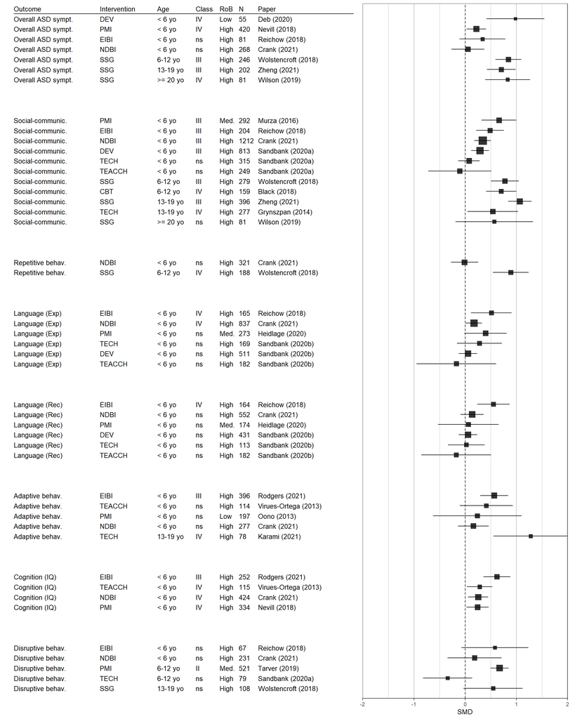

```r
colnames(res.main)[colnames(res.main) == "Effect_size"] <- "Effect size"
colnames(res.main)[colnames(res.main) == "Sample_size_studies"] <- "Sample size (studies)"
colnames(res.main)[colnames(res.main) == "Type_of_outcome"] <- "Type of outcome"
colnames(res.main)[colnames(res.main) == "Active_controls"] <- "% of active controls"
colnames(res.main)[colnames(res.main) == "Risk_of_bias"] <- "Risk of bias"
res.main$amstar <- paste0(res.main$amstar, "/5")

res.main$Outcome <- rename_outcome(res.main$Outcome)
res.prim.1 <- res.main[, display.cols]
res.prim <- res.prim.1[which(res.prim.1$IN_meta == 1), ]

res.prim$Age <- factor(res.prim$Age, levels = c("< 6 yo", "6-12 yo", "13-19 yo", ">= 20 yo"))
res.prim$Class <- factor(res.prim$Class, levels = c("I", "II", "III", "IV", "ns"))
res.prim$Outcome <- factor(res.prim$Outcome,
                                levels = c("Overall ASD sympt.",
                                           "Social-communic.",
                                           "Repetitive behav.",
                                           "Language (Exp)",
                                           "Language (Rec)",
                                           "Adaptive behav.",
                                           "Cognition (IQ)",
                                           "Disruptive behav."))

res.prim <- res.prim[order(res.prim$Outcome,res.prim$Class, res.prim$Age, decreasing = FALSE),]
res.prim <- res.prim[order(res.prim$Age),]

tab.prim <- data.frame(
  Outcome = res.prim$Outcome,
  Intervention = res.prim$Intervention,
  Age = res.prim$Age,
  Class = res.prim$Class,
  RoB = res.prim$'Risk of bias',
  N = round(res.prim$total_n),
  Paper = res.prim$Paper)

forest_modif(x = res.prim[, c("value", "se")],
           variant = "classic",
           col = "Greys", xlab = "SMD", annotate_CI = FALSE,
           study_table = tab.prim,
           group = tab.prim$Outcome,
           type = "study_only",
           text_size = 3.6,
           x_limit = c(-2, 2),
           N = res.prim$total_n,
           x_breaks = seq(-3, 3, 1))
```

### Table

```r
DT::datatable(res.prim[, 1:24],
              rownames = FALSE,
              options = list(  # options
                scrollX = TRUE,
                dom = c('ft'),
                scrollY = "600px",
                pageLength = 600,
                order = list(3, 'asc'),
                autoWidth = TRUE,
                columnDefs = list(
                  list(width = '110px',
                       targets = "_all"),
                  list(className = 'dt-center',
                                     targets = "_all"))))
```

| Paper | Intervention | Intervention_precise | Outcome | Class | Sample size (studies) | Effect size | p_value | PI_eG | I2 | egger_p | ESB_p | largest_CI_eG | amstar | Risk of bias | Age | Age_bounds | IQ | Type of outcome | % of active controls | Intensity | Duration | Implementer | Setting |
| --- | --- | --- | --- | --- | --- | --- | --- | --- | --- | --- | --- | --- | --- | --- | --- | --- | --- | --- | --- | --- | --- | --- | --- |
| Deb (2020) | DEV | DEV | Overall ASD sympt. | IV | 55 (2) | SMD = 0.98 [0.413, 1.546] | 6.96e-04 | &lt; 3 studies | 0 | &lt; 3 studies | 2.95e-01 | [0.034, 1.569] | 3/5 | Low | &lt; 6 yo | [4 - 4.5] | Low (&lt; 70) |  | 44% | 10-19 h/wk | 2-6 months | Caregiver | Home |
| Nevill (2018) | PMI | PMI | Overall ASD sympt. | IV | 420 (6) | SMD = 0.217 [0.025, 0.41] | 2.71e-02 | [-0.056, 0.49] | 0 | 1.49e-01 | 4.23e-01 | [-0.191, 0.464] | 1/5 | High | &lt; 6 yo | [1.6 - 4.1] | Low (&lt; 70) | Report | 31% | 2-4 h/wk | 7-12 months | Caregiver | Home |
| Reichow (2018) | EIBI | EIBI | Overall ASD sympt. | ns | 81 (2) | SMD = 0.338 [-0.111, 0.787] | 1.41e-01 | &lt; 3 studies | 0 | &lt; 3 studies | 1.00e+00 | [-0.204, 1.097] | 5/5 | High | &lt; 6 yo | [3.1 - 3.3] | Low (&lt; 70) | Report | 0% | &gt;= 20h/wk | &gt; 12 months | Profesionnal | Home |
| Crank (2021) | NDBI | NDBI | Overall ASD sympt. | ns | 268 (6) | SMD = 0.055 [-0.266, 0.375] | 7.39e-01 | [-0.793, 0.902] | 42.772 | 9.03e-01 | 1.00e+00 | [-0.585, 0.432] | 3/5 | High | &lt; 6 yo | [2 - 5.8] | Low (&lt; 70) | Observation | 38% | 10-19 h/wk | 7-12 months | Caregiver | Home |
| Murza (2016) | PMI | PMI | Social-communic. | III | 292 (5) | SMD = 0.66 [0.32, 1] | 1.42e-04 | [-0.312, 1.632] | 44.157 | 8.52e-01 | 7.76e-01 | [0.392, 1.046] | 2.5/5 | Med. | &lt; 6 yo | [1.8 - 4.1] | Low (&lt; 70) | Observation | 0% | 2-4 h/wk | 7-12 months | Caregiver | Home |
| Reichow (2018) | EIBI | EIBI | Social-communic. | III | 204 (5) | SMD = 0.484 [0.213, 0.755] | 4.66e-04 | [0.044, 0.924] | 0 | 9.25e-02 | 9.35e-01 | [0.139, 1.324] | 5/5 | High | &lt; 6 yo | [2.6 - 3.3] | Low (&lt; 70) | Report | 0% | &gt;= 20h/wk | &gt; 12 months | Profesionnal | Home |
| Crank (2021) | NDBI | NDBI | Social-communic. | III | 1212 (24) | SMD = 0.34 [0.178, 0.503] | 3.90e-05 | [-0.263, 0.944] | 51.097 | 3.08e-01 | 1.49e-02 | [-0.21, 0.392] | 3/5 | High | &lt; 6 yo | [1.5 - 6.3] | Low (&lt; 70) | Observation | 25% | 5-9 h/wk | 7-12 months | Profesionnal | Home |
| Sandbank (2020a) | DEV | DEV | Social-communic. | III | 813 (14) | SMD = 0.29 [0.118, 0.463] | 9.79e-04 | [-0.148, 0.728] | 28.702 | 6.68e-01 | 3.87e-02 | [-0.147, 0.468] | 3/5 | High | &lt; 6 yo | [1.8 - 7.4] | Limit (70-79) | Observation | 9% | 5-9 h/wk | 7-12 months | Caregiver | Home |
| Sandbank (2020a) | TECH | TECH | Social-communic. | ns | 315 (9) | SMD = 0.075 [-0.135, 0.284] | 4.86e-01 | [-0.178, 0.328] | 0 | 1.78e-01 | 1.00e+00 | [-0.22, 0.767] | 3/5 | High | &lt; 6 yo | [3.3 - 7.8] | Average (80-119) | Report | 0% | &lt; 2 h/wk | 2-6 months | Profesionnal | Home |
| Sandbank (2020a) | TEACCH | TEACCH | Social-communic. | ns | 249 (6) | SMD = -0.105 [-0.723, 0.512] | 7.38e-01 | [-2.125, 1.914] | 72.995 | 6.87e-01 | 6.69e-01 | [-0.657, 0.015] | 3/5 | High | &lt; 6 yo | [2.5 - 5.3] | Low (&lt; 70) | Test | 0% | 10-19 h/wk | 7-12 months | Profesionnal | School |

[output cut: 36 more lines]

### Synthesis

Pooled ES

```r
synt.main = subset(res.main, IN_meta == 1)
synt.main$ES_comb = paste(synt.main$value, " ", synt.main$value_CI)
synt.main.ES = synt.main[,c("Intervention", "Outcome", "ES_comb", "Age")] %>%
                  tidyr::pivot_wider(names_from = Outcome, values_from = ES_comb)


synt.main.ES$Age <- ordered(synt.main.ES$Age, levels = c("< 6 yo", "6-12 yo", "13-19 yo", ">= 20 yo"))
synt.main.ES <- synt.main.ES[order(synt.main.ES$Intervention, synt.main.ES$Age), ]
synt.main.ES$Intervention = paste0(synt.main.ES$Intervention, " (", synt.main.ES$Age, ")")
# res.prim$Class <- factor(res.prim$Class, levels = c("I", "II", "III", "IV", "ns"))
# arrange(synt.main.ES, Intervention, Age)

synt.main.ES[is.na(synt.main.ES)] <- "Not assessed"
DT::datatable(subset(synt.main.ES, select = -c(Age)),
              rownames = FALSE,
              options = list(  # options
                scrollX = TRUE,
                pageLength = 1600,
                dom = c('t'),
                autoWidth = TRUE,
                columnDefs = list(
                  list(width = '150px',
                       targets = "_all"),
                  list(className = 'dt-center',
                                     targets = "_all"))))
```

| Intervention | Disruptive behav. | Social-communic. | Overall ASD sympt. | Cognition (IQ) | Adaptive behav. | Repetitive behav. | Language (Rec) | Language (Exp) |
| --- | --- | --- | --- | --- | --- | --- | --- | --- |
| CBT (6-12 yo) | Not assessed | 0.704 [0.408, 1] | Not assessed | Not assessed | Not assessed | Not assessed | Not assessed | Not assessed |
| DEV (&lt; 6 yo) | Not assessed | 0.29 [0.118, 0.463] | 0.98 [0.413, 1.546] | Not assessed | Not assessed | Not assessed | 0.055 [-0.124, 0.235] | 0.055 [-0.126, 0.236] |
| EIBI (&lt; 6 yo) | 0.582 [-0.072, 1.236] | 0.484 [0.213, 0.755] | 0.338 [-0.111, 0.787] | 0.618 [0.355, 0.881] | 0.566 [0.294, 0.838] | Not assessed | 0.55 [0.233, 0.867] | 0.512 [0.115, 0.909] |
| NDBI (&lt; 6 yo) | 0.184 [-0.346, 0.713] | 0.34 [0.178, 0.503] | 0.055 [-0.266, 0.375] | 0.254 [0.056, 0.451] | 0.16 [-0.14, 0.459] | -0.013 [-0.278, 0.252] | 0.136 [-0.09, 0.362] | 0.171 [0.013, 0.33] |
| PMI (&lt; 6 yo) | Not assessed | 0.66 [0.32, 1] | 0.217 [0.025, 0.41] | 0.242 [0.026, 0.458] | 0.238 [-0.627, 1.104] | Not assessed | 0.062 [-0.529, 0.653] | 0.399 [-0.012, 0.809] |
| PMI (6-12 yo) | 0.671 [0.491, 0.85] | Not assessed | Not assessed | Not assessed | Not assessed | Not assessed | Not assessed | Not assessed |
| SSG (6-12 yo) | Not assessed | 0.776 [0.504, 1.048] | 0.844 [0.591, 1.097] | Not assessed | Not assessed | 0.889 [0.54, 1.238] | Not assessed | Not assessed |
| SSG (13-19 yo) | 0.545 [-0.034, 1.123] | 1.067 [0.838, 1.295] | 0.705 [0.423, 0.987] | Not assessed | Not assessed | Not assessed | Not assessed | Not assessed |
| SSG (&gt;= 20 yo) | Not assessed | 0.568 [-0.189, 1.324] | 0.829 [0.389, 1.269] | Not assessed | Not assessed | Not assessed | Not assessed | Not assessed |
| TEACCH (&lt; 6 yo) | Not assessed | -0.105 [-0.723, 0.512] | Not assessed | 0.285 [0.037, 0.532] | 0.412 [-0.108, 0.932] | Not assessed | -0.175 [-0.858, 0.508] | -0.172 [-0.948, 0.603] |

[output cut: 3 more lines]

Selected meta-analyses

```r
synt.main = subset(res.main, IN_meta == 1)
synt.main.ES = synt.main[,c("Intervention", "Outcome", "Paper", "Age")] %>%
                  tidyr::pivot_wider(names_from = Outcome, values_from = Paper)


synt.main.ES$Age <- ordered(synt.main.ES$Age, levels = c("< 6 yo", "6-12 yo", "13-19 yo", ">= 20 yo"))
synt.main.ES <- synt.main.ES[order(synt.main.ES$Intervention, synt.main.ES$Age), ]
synt.main.ES$Intervention = paste0(synt.main.ES$Intervention, " (", synt.main.ES$Age, ")")
# res.prim$Class <- factor(res.prim$Class, levels = c("I", "II", "III", "IV", "ns"))
# arrange(synt.main.ES, Intervention, Age)

synt.main.ES[is.na(synt.main.ES)] <- "Not assessed"
DT::datatable(subset(synt.main.ES, select = -c(Age)),
              rownames = FALSE,
              options = list(  # options
                scrollX = TRUE,
                pageLength = 1600,
                dom = c('t'),
                autoWidth = TRUE,
                columnDefs = list(
                  list(width = '150px',
                       targets = "_all"),
                  list(className = 'dt-center',
                                     targets = "_all"))))
```

| Intervention | Disruptive behav. | Social-communic. | Overall ASD sympt. | Cognition (IQ) | Adaptive behav. | Repetitive behav. | Language (Rec) | Language (Exp) |
| --- | --- | --- | --- | --- | --- | --- | --- | --- |
| CBT (6-12 yo) | Not assessed | Black (2018) | Not assessed | Not assessed | Not assessed | Not assessed | Not assessed | Not assessed |
| DEV (&lt; 6 yo) | Not assessed | Sandbank (2020a) | Deb (2020) | Not assessed | Not assessed | Not assessed | Sandbank (2020b) | Sandbank (2020b) |
| EIBI (&lt; 6 yo) | Reichow (2018) | Reichow (2018) | Reichow (2018) | Rodgers (2021) | Rodgers (2021) | Not assessed | Reichow (2018) | Reichow (2018) |
| NDBI (&lt; 6 yo) | Crank (2021) | Crank (2021) | Crank (2021) | Crank (2021) | Crank (2021) | Crank (2021) | Crank (2021) | Crank (2021) |
| PMI (&lt; 6 yo) | Not assessed | Murza (2016) | Nevill (2018) | Nevill (2018) | Oono (2013) | Not assessed | Heidlage (2020) | Heidlage (2020) |
| PMI (6-12 yo) | Tarver (2019) | Not assessed | Not assessed | Not assessed | Not assessed | Not assessed | Not assessed | Not assessed |
| SSG (6-12 yo) | Not assessed | Wolstencroft (2018) | Wolstencroft (2018) | Not assessed | Not assessed | Wolstencroft (2018) | Not assessed | Not assessed |
| SSG (13-19 yo) | Wolstencroft (2018) | Zheng (2021) | Zheng (2021) | Not assessed | Not assessed | Not assessed | Not assessed | Not assessed |
| SSG (&gt;= 20 yo) | Not assessed | Wilson (2019) | Wilson (2019) | Not assessed | Not assessed | Not assessed | Not assessed | Not assessed |
| TEACCH (&lt; 6 yo) | Not assessed | Sandbank (2020a) | Not assessed | Virues-Ortega (2013) | Virues-Ortega (2013) | Not assessed | Sandbank (2020b) | Sandbank (2020b) |

[output cut: 3 more lines]

# S2. Supplementary analyses

## A. Low RoB

This first sensitivity analysis restricts to low risk of bias studies (i.e., RCTs at low risk of detection bias)

### Data analysis

```r
df.S1 <- subset(df_raw_S1, factor %in% unique(subset(res.main, IN_meta == 1)$factor))
umb.S1 <- metaumbrella::umbrella(df.S1, mult.level = TRUE, method.var = "REML", r = 0.8, verbose = FALSE)

res.transit.S1 <- metaumbrella::add.evidence(umb.S1,
    criteria = "Personalised",
    class_I = c(total_n = 500, p_value = 1e-3, I2 = 50,
                egger_p = .05, pi = "notnull",
                rob = 75, amstar = 4.99),
    class_II = c(total_n = 350, p_value = 1e-3,
                largest_CI = "notnull",
                rob = 50, amstar = 3.99),
    class_III = c(total_n = 200, p_value = 1e-3),
    class_IV = c(p_value = 5e-2), verbose = FALSE)

res.S1 <- metaumbrella::summary.umbrella(res.transit.S1)
res.S1 <- gen_id(res.S1$Factor, res.S1)
```

```r
# merge datasets
res.S1$factor = res.S1$Factor
res.main.S1 <- dplyr::left_join(res.S1, df_agg_meta_S1)

# estimate the STANDARD ERROR of the pooled ES
ci_lo_transit <- ci_up_transit <- CI_up <- CI_lo <- NA
for (i in 1:nrow(res.main.S1)) {
    ci_lo_transit[i] <- gsub(",.*", "", res.main.S1$value_CI[i])
    ci_up_transit[i] <- gsub(".*, ", "", res.main.S1$value_CI[i])
    CI_lo[i] <- gsub("\\[", "", ci_lo_transit[i])
    CI_up[i] <- gsub("]", "", ci_up_transit[i])
}
CI_lo <- as.numeric(as.character(CI_lo))
CI_up <- as.numeric(as.character(CI_up))
res.main.S1$se <- (CI_up - CI_lo) / 3.92

# Create/recode some variables
res.main.S1$total_n <- round(res.main.S1$total_n)
res.main.S1$Class <- ifelse(res.main.S1$Class == "V", "ns", as.character(res.main.S1$Class))
res.main.S1$Sample_size_studies <- with(res.main.S1, paste0(total_n, " (", n_studies, ")"))
res.main.S1$Effect_size <- paste0("SMD = ", res.main.S1$value, " [", CI_lo, ", ", CI_up, "]")
res.main.S1$Risk_of_bias <- with(res.main.S1, ifelse(rob < 50, "High",
                                               ifelse(rob < 75, "Med.", ifelse(rob >= 75, "Low", NA_real_))))
res.main.S1$Active_controls <- paste0(round(res.main.S1$Active_controls), "%")

# Identify main characteristics (setting, outcome type, therapy implementer)
res.main.S1 = main_characteristics(res.main.S1)
```

### Plot

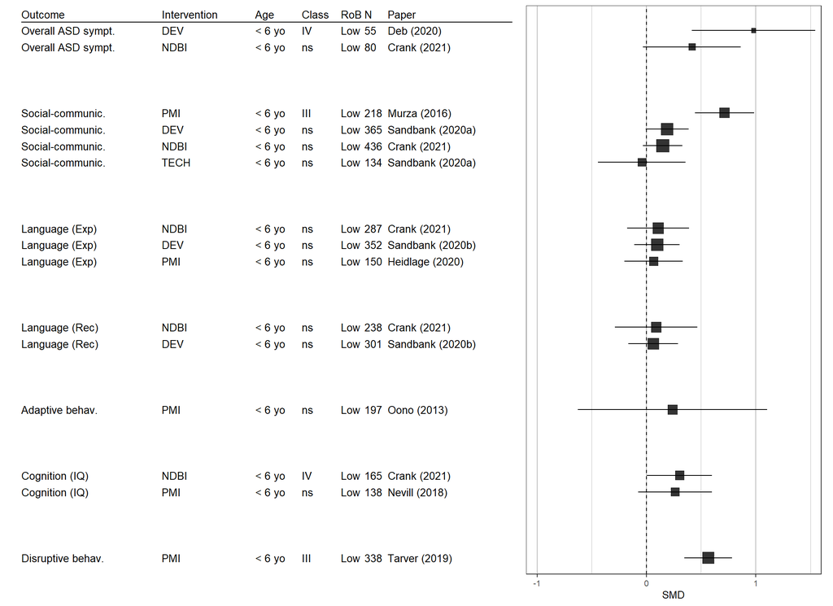

```r
res.S1.sub <- subset(res.main.S1, n_studies >= 2)
colnames(res.S1.sub)[colnames(res.S1.sub) == "Effect_size"] <- "Effect size"
colnames(res.S1.sub)[colnames(res.S1.sub) == "Sample_size_studies"] <- "Sample size (studies)"
colnames(res.S1.sub)[colnames(res.S1.sub) == "Type_of_outcome"] <- "Type of outcome"
colnames(res.S1.sub)[colnames(res.S1.sub) == "Active_controls"] <- "% of active controls"
colnames(res.S1.sub)[colnames(res.S1.sub) == "Risk_of_bias"] <- "Risk of bias"

res.S1.sub$Outcome <- rename_outcome(res.S1.sub$Outcome)

res.S1.2 <- res.S1.sub[, display.cols[display.cols != "IN_meta"]]

res.S1.2 <- res.S1.2[order(res.S1.2$Outcome,res.S1.2$Class, res.S1.2$Age, decreasing = FALSE),]
res.S1.2 <- res.S1.2[order(res.S1.2$Age),]

res.S1.2$Age <- factor(res.S1.2$Age, levels = c("< 6 yo", "6-12 yo", "13-19 yo", ">= 20 yo"))
res.S1.2$Class <- factor(res.S1.2$Class, levels = c("I", "II", "III", "IV", "ns"))
res.S1.2$Outcome <- factor(res.S1.2$Outcome,
                                levels = c("Overall ASD sympt.",
                                           "Social-communic.",
                                           "Repetitive behav.",
                                           "Language (Exp)",
                                           "Language (Rec)",
                                           "Adaptive behav.",
                                           "Cognition (IQ)",
                                           "Disruptive behav."))


tab.S1 <- data.frame(
  Outcome = res.S1.2$Outcome,
  Intervention = res.S1.2$Intervention,
  Age = res.S1.2$Age,
  Class = res.S1.2$Class,
  RoB = res.S1.2$'Risk of bias',
  N = round(res.S1.2$total_n),
  Paper = res.S1.2$Paper)

forest_modif(x = res.S1.2[, c("value", "se")],
           variant = "classic",
           col = "Greys", xlab = "SMD", annotate_CI = F,
           study_table = tab.S1,
           group = tab.S1$Outcome,
           type = "study_only",
           text_size = 3.5,
           x_limit = c(-1.1, 1.6),
           N = res.S1.2$total_n,
           x_breaks = seq(-3, 3, 1))
```

### Table

```r
DT::datatable(res.S1.2,
              rownames = FALSE,
              options = list(  # options
                scrollX = TRUE,
                dom = c('ft'),
                scrollY = "600px",
                pageLength = 600,
                order = list(3, 'asc'),
                autoWidth = TRUE,
                columnDefs = list(
                  list(width = '110px',
                       targets = "_all"),
                  list(className = 'dt-center',
                                     targets = "_all"))))
```

| Paper | Intervention | Intervention_precise | Outcome | Class | Sample size (studies) | Effect size | p_value | PI_eG | I2 | egger_p | ESB_p | largest_CI_eG | amstar | Risk of bias | Age | Age_bounds | IQ | Type of outcome | % of active controls | Intensity | Duration | Implementer | Setting | total_n | value | se |
| --- | --- | --- | --- | --- | --- | --- | --- | --- | --- | --- | --- | --- | --- | --- | --- | --- | --- | --- | --- | --- | --- | --- | --- | --- | --- | --- |
| Oono (2013) | PMI | PMI | Adaptive behav. | ns | 197 (2) | SMD = 0.238 [-0.627, 1.104] | 5.89e-01 | &lt; 3 studies | 84.477 | &lt; 3 studies | 2.43e-01 | [-0.487, 0.155] | 5 | Low | &lt; 6 yo | [2 - 3.8] | Low (&lt; 70) | Report | 0% | 10-19 h/wk | &gt; 12 months | Caregiver | Home | 197 | 0.238 | 0.441581632653061 |
| Crank (2021) | NDBI | NDBI | Cognition (IQ) | IV | 165 (4) | SMD = 0.303 [0.005, 0.601] | 4.61e-02 | [-0.351, 0.957] | 0 | 6.69e-01 | 1.00e+00 | [-0.27, 0.826] | 3 | Low | &lt; 6 yo | [2 - 3.6] | Low (&lt; 70) | Test | 30% | 10-19 h/wk | 7-12 months | Profesionnal | Clinic | 165 | 0.303 | 0.152040816326531 |
| Nevill (2018) | PMI | PMI | Cognition (IQ) | ns | 138 (2) | SMD = 0.262 [-0.074, 0.598] | 1.26e-01 | &lt; 3 studies | 0 | &lt; 3 studies | 1.00e+00 | [-0.175, 0.626] | 1 | Low | &lt; 6 yo | [3.7 - 4.2] | Low (&lt; 70) | Test | 28% | &lt; 2 h/wk | 7-12 months | Caregiver | Home | 138 | 0.262 | 0.171428571428571 |
| Tarver (2019) | PMI | PMI | Disruptive behav. | III | 338 (4) | SMD = 0.565 [0.347, 0.783] | 3.94e-07 | [0.086, 1.044] | 0 | 5.58e-01 | 8.61e-01 | [0.275, 0.876] | 4 | Low | &lt; 6 yo | [4.7 - 8] | Average (80-119) | Report | 53% | &lt; 2 h/wk | 2-6 months | Caregiver | Clinic | 338 | 0.565 | 0.111224489795918 |
| Crank (2021) | NDBI | NDBI | Language (Exp) | ns | 287 (6) | SMD = 0.107 [-0.177, 0.391] | 4.61e-01 | [-0.571, 0.785] | 25.896 | 6.75e-01 | 1.00e+00 | [-0.535, 0.323] | 3 | Low | &lt; 6 yo | [2 - 4.1] | Low (&lt; 70) | Test | 49% | 5-9 h/wk | 7-12 months | Profesionnal | Home | 287 | 0.107 | 0.144897959183673 |
| Sandbank (2020b) | DEV | DEV | Language (Exp) | ns | 352 (4) | SMD = 0.097 [-0.111, 0.305] | 3.59e-01 | [-0.359, 0.553] | 0 | 5.95e-01 | 1.00e+00 | [-0.32, 0.32] | 3 | Low | &lt; 6 yo | [1.8 - 4.2] | Low (&lt; 70) | Test | 0% | 5-9 h/wk | 7-12 months | Caregiver | Home | 352 | 0.097 | 0.106122448979592 |
| Heidlage (2020) | PMI | PMI | Language (Exp) | ns | 150 (2) | SMD = 0.064 [-0.203, 0.331] | 6.39e-01 | &lt; 3 studies | 0 | &lt; 3 studies | 1.00e+00 | [-0.4, 0.35] | 3 | Low | &lt; 6 yo | [3.7 - 4.2] | Limit (70-79) | Test | 0% | 5-9 h/wk | 7-12 months | Caregiver | Home | 150 | 0.064 | 0.136224489795918 |
| Crank (2021) | NDBI | NDBI | Language (Rec) | ns | 238 (5) | SMD = 0.089 [-0.287, 0.465] | 6.43e-01 | [-1.031, 1.209] | 46.449 | 7.51e-01 | 1.00e+00 | [-0.541, 0.317] | 3 | Low | &lt; 6 yo | [2 - 4.1] | Low (&lt; 70) | Test | 39% | 5-9 h/wk | 7-12 months | Profesionnal | Home | 238 | 0.089 | 0.191836734693878 |
| Sandbank (2020b) | DEV | DEV | Language (Rec) | ns | 301 (3) | SMD = 0.061 [-0.166, 0.288] | 5.99e-01 | [-1.409, 1.531] | 0 | 4.21e-01 | 1.00e+00 | [-0.228, 0.413] | 3 | Low | &lt; 6 yo | [1.8 - 4.2] | Low (&lt; 70) | Test | 0% | 2-4 h/wk | 7-12 months | Caregiver | Home | 301 | 0.061 | 0.115816326530612 |
| Deb (2020) | DEV | DEV | Overall ASD sympt. | IV | 55 (2) | SMD = 0.98 [0.413, 1.546] | 6.96e-04 | &lt; 3 studies | 0 | &lt; 3 studies | 2.95e-01 | [0.034, 1.569] | 3 | Low | &lt; 6 yo | [4 - 4.5] | Low (&lt; 70) |  | 44% | 10-19 h/wk | 2-6 months | Caregiver | Home | 55 | 0.98 | 0.289030612244898 |

[output cut: 5 more lines]

```r
paste0("The number of meta-analyses with a SMD >= 0.5 is equal to ", nrow(res.prim[res.prim$value >= 0.5,]), " (", round(nrow(res.prim[res.prim$value >= 0.5,]) / nrow(res.prim), 3) * 100, "%)", " in our primary analysis but equal to ", nrow(res.S1.2[res.S1.2$value >= 0.5,]), " (", round(nrow(res.S1.2[res.S1.2$value >= 0.5,]) / nrow(res.S1.2), 3) * 100, "%) in this sensitivity analysis, and the number of meta-analyses with a statistically significant p-value (p<.05) is equal to ", nrow(res.prim[as.numeric(res.prim$p_value) < 0.05,]), " (", round(nrow(res.prim[as.numeric(res.prim$p_value) < 0.05,]) / nrow(res.prim), 3) * 100, "%)", " in our primary analysis but equal to ", nrow(res.S1.2[as.numeric(res.S1.2$p_value) < 0.05,]), " (", round(nrow(res.S1.2[as.numeric(res.S1.2$p_value) < 0.05,]) / nrow(res.S1.2), 3) * 100, "%) in this sensitivity analysis.")
```

```
## [1] "The number of meta-analyses with a SMD >= 0.5 is equal to 19 (41.3%) in our primary analysis but equal to 3 (20%) in this sensitivity analysis, and the number of meta-analyses with a statistically significant p-value (p<.05) is equal to 24 (52.2%) in our primary analysis but equal to 4 (26.7…
```

## B. Non-selected MAs

This section presents results of overlapping meta-analyses. To facilitate presentation, each tab contains all meta-analyses for each intervention types

### 1. EIBI

#### Plot

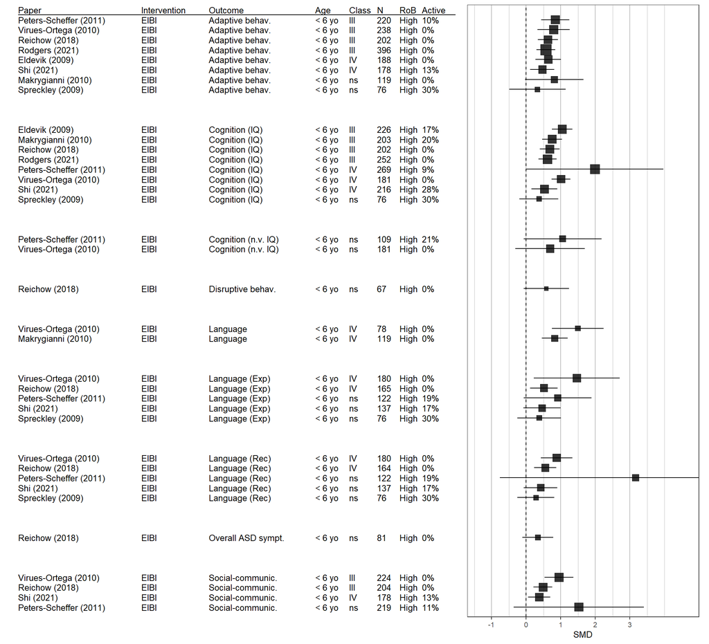

```r
res.eibi <- res.main[which(grepl("EIBI", res.main$Intervention, fixed = TRUE)), display.cols]
res.eibi <- res.eibi[order(res.eibi$Class, decreasing = FALSE), ]
res.eibi <- res.eibi[order(res.eibi$Outcome, decreasing = TRUE), ]


tab.eibi <- data.frame(
  Paper = res.eibi$Paper,
  Intervention = res.eibi$Intervention,
  Outcome = res.eibi$Outcome,
  Age = res.eibi$Age,
  Class = res.eibi$Class,
  N = paste0(res.eibi$total_n," "),
  RoB = res.eibi$'Risk of bias',
  Active = res.eibi$`% of active controls`)

forest_modif(x = res.eibi[, c("value", "se")],
           variant = "classic",
           col = "Greys", xlab = "SMD", annotate_CI = FALSE,
           study_table = tab.eibi,
           group = tab.eibi$Outcome,
           type = "study_only",
           text_size = 3.4,
           x_limit = c(-1.7, 5),
           N = res.eibi$total_n,
           x_breaks = seq(-3, 3, 1))
```

#### Table

```r
DT::datatable(res.eibi[, 1:24],
              rownames = FALSE,
              options = list(  # options
                scrollX = TRUE,
                dom = c('ft'),
                scrollY = "600px",
                pageLength = 600,
                order = list(3, 'asc'),
                autoWidth = TRUE,
                columnDefs = list(
                  list(width = '110px',
                       targets = "_all"),
                  list(className = 'dt-center',
                                     targets = "_all"))))
```

| Paper | Intervention | Intervention_precise | Outcome | Class | Sample size (studies) | Effect size | p_value | PI_eG | I2 | egger_p | ESB_p | largest_CI_eG | amstar | Risk of bias | Age | Age_bounds | IQ | Type of outcome | % of active controls | Intensity | Duration | Implementer | Setting |
| --- | --- | --- | --- | --- | --- | --- | --- | --- | --- | --- | --- | --- | --- | --- | --- | --- | --- | --- | --- | --- | --- | --- | --- |
| Virues-Ortega (2010) | EIBI | EIBI | Social-communic. | III | 224 (6) | SMD = 0.946 [0.528, 1.363] | 9.06e-06 | [-0.303, 2.194] | 59.301 | 1.60e-02 | 1.29e-02 | [-0.17, 0.872] | 3/5 | High | &lt; 6 yo | [2.6 - 5.5] | Low (&lt; 70) | Report | 0% | &gt;= 20h/wk | &gt; 12 months | Profesionnal | Home |
| Reichow (2018) | EIBI | EIBI | Social-communic. | III | 204 (5) | SMD = 0.484 [0.213, 0.755] | 4.66e-04 | [0.044, 0.924] | 0 | 9.25e-02 | 9.35e-01 | [0.139, 1.324] | 5/5 | High | &lt; 6 yo | [2.6 - 3.3] | Low (&lt; 70) | Report | 0% | &gt;= 20h/wk | &gt; 12 months | Profesionnal | Home |
| Shi (2021) | EIBI | EIBI | Social-communic. | IV | 178 (5) | SMD = 0.377 [0.056, 0.697] | 2.13e-02 | [-0.367, 1.121] | 23.012 | 6.95e-01 | 9.81e-01 | [0.19, 1.57] | 4/5 | High | &lt; 6 yo | [2.5 - 3] | Low (&lt; 70) | Report | 13% | &gt;= 20h/wk | &gt; 12 months | Profesionnal | Home |
| Peters-Scheffer (2011) | EIBI | EIBI | Social-communic. | ns | 219 (6) | SMD = 1.522 [-0.362, 3.406] | 1.13e-01 | [-5.435, 8.48] | 93.327 | 2.46e-02 | 1.00e+00 | [5.178, 7.901] | 2/5 | High | &lt; 6 yo | [2.8 - 5.5] | Low (&lt; 70) | Report | 11% | &gt;= 20h/wk | &gt; 12 months | Profesionnal | Home |
| Reichow (2018) | EIBI | EIBI | Overall ASD sympt. | ns | 81 (2) | SMD = 0.338 [-0.111, 0.787] | 1.41e-01 | &lt; 3 studies | 0 | &lt; 3 studies | 1.00e+00 | [-0.204, 1.097] | 5/5 | High | &lt; 6 yo | [3.1 - 3.3] | Low (&lt; 70) | Report | 0% | &gt;= 20h/wk | &gt; 12 months | Profesionnal | Home |
| Virues-Ortega (2010) | EIBI | EIBI | Language (Rec) | IV | 180 (5) | SMD = 0.878 [0.421, 1.335] | 1.67e-04 | [-0.655, 2.41] | 63.814 | 1.22e-02 | 1.10e-01 | [0.157, 1.1] | 3/5 | High | &lt; 6 yo | [2.6 - 5.5] | Low (&lt; 70) | Test | 0% | &gt;= 20h/wk | &gt; 12 months | Profesionnal | School |
| Reichow (2018) | EIBI | EIBI | Language (Rec) | IV | 164 (4) | SMD = 0.55 [0.233, 0.867] | 6.67e-04 | [-0.145, 1.245] | 0 | 4.19e-01 | 9.95e-01 | [0.262, 1.418] | 5/5 | High | &lt; 6 yo | [2.6 - 3.3] | Low (&lt; 70) | Test | 0% | &gt;= 20h/wk | &gt; 12 months | Profesionnal | Home |
| Peters-Scheffer (2011) | EIBI | EIBI | Language (Rec) | ns | 122 (4) | SMD = 3.166 [-0.764, 7.095] | 1.14e-01 | [-15.724, 22.055] | 95.878 | 2.96e-01 | 1.00e+00 | [3.353, 5.486] | 2/5 | High | &lt; 6 yo | [2.8 - 5.5] | Low (&lt; 70) | Test | 19% | &gt;= 20h/wk | &gt; 12 months | Profesionnal | School |
| Shi (2021) | EIBI | EIBI | Language (Rec) | ns | 137 (4) | SMD = 0.417 [-0.068, 0.903] | 9.22e-02 | [-1.43, 2.265] | 50.262 | 4.67e-01 | 9.98e-01 | [0.3, 1.66] | 4/5 | High | &lt; 6 yo | [2.5 - 3] | Low (&lt; 70) |  | 17% | &gt;= 20h/wk | &gt; 12 months | Profesionnal | Home |
| Spreckley (2009) | EIBI | EIBI | Language (Rec) | ns | 76 (3) | SMD = 0.28 [-0.256, 0.817] | 3.05e-01 | [-4.386, 4.947] | 28.35 | 5.60e-01 | 1.00e+00 | [-0.312, 1.272] | 1/5 | High | &lt; 6 yo | [2.8 - 5.4] | Low (&lt; 70) | Test | 30% | &gt;= 20h/wk | &gt; 12 months | Profesionnal | School |

[output cut: 26 more lines]

#### Discrepancy

```r
df.EIBI.disc <- subset(df_raw, grepl("EIBI", df_raw$Intervention_general, fixed = TRUE) & IN_trial == 1)

df.EIBI.disc$factor <- df.EIBI.disc$Outcome_general
df.EIBI.disc$amstar = min(df.EIBI.disc$amstar)

errors <- metaumbrella::view.errors.umbrella(df.EIBI.disc, return = "data")

df.EIBI.disc$multiple_es[which(df.EIBI.disc$row_id %in% errors[which(errors$column_type_errors == "ERROR"), ]$row_id)] = "outcomes"

umb.EIBI.disc <- metaumbrella::umbrella(df.EIBI.disc, mult.level = TRUE, verbose = FALSE)
res.EIBI.disc = metaumbrella::summary.umbrella(metaumbrella::add.evidence(umb.EIBI.disc,
                  criteria = "Personalized",
                  class_I = c(total_n = 500, p_value = 1e-3, I2 = 50,
                              egger_p = .05, pi = "notnull",
                              rob = 75),
                  class_II = c(total_n = 350, p_value = 1e-3,
                              largest_CI = "notnull",
                              rob = 50),
                  class_III = c(total_n = 200, p_value = 1e-3),
                  class_IV = c(p_value = 5e-2), verbose = FALSE))

res.EIBI.disc_comp = res.EIBI.disc[res.EIBI.disc$Factor %in% mainsympt, ]
res.EIBI.disc_comp = res.EIBI.disc_comp[order(res.EIBI.disc_comp$Factor), ]
res.EIBI.disc_comp = res.EIBI.disc_comp[, c("Factor", "Class", "measure", "value", "value_CI", "p_value", "n_studies", "total_n")]

res.main.EIBI_comp = res.main[res.main$Outcome_general %in% mainsympt & res.main$Intervention == "EIBI" & res.main$IN_meta == 1, ]
res.main.EIBI_comp = res.main.EIBI_comp[order(res.main.EIBI_comp$Outcome_general), ]
res.main.EIBI_comp = res.main.EIBI_comp[, c("Factor", "Class", "measure", "value", "value_CI", "p_value", "n_studies", "total_n")]
colnames(res.main.EIBI_comp) <- paste0(colnames(res.main.EIBI_comp), "_main")
colnames(res.EIBI.disc_comp) <- paste0(colnames(res.EIBI.disc_comp), "_tot")

DT::datatable(cbind(res.main.EIBI_comp, res.EIBI.disc_comp),
              rownames = FALSE,
              options = list(  # options
                scrollX = TRUE,
                autoWidth = TRUE,
                columnDefs = list(
                  list(width = '110px',
                       targets = "_all"),
                  list(className = 'dt-center',
                                     targets = "_all"))))
```

| Factor_main | Class_main | measure_main | value_main | value_CI_main | p_value_main | n_studies_main | total_n_main | Factor_tot | Class_tot | measure_tot | value_tot | value_CI_tot | p_value_tot | n_studies_tot | total_n_tot |
| --- | --- | --- | --- | --- | --- | --- | --- | --- | --- | --- | --- | --- | --- | --- | --- |
| Rodgers_2021_EIBI_Adaptive behaviors | III | G | 0.566 | [0.294, 0.838] | 4.60e-05 | 10 | 396 | Adaptive behaviors | III | G | 0.47 | [0.238, 0.703] | 7.48e-05 | 14 | 509 |
| Rodgers_2021_EIBI_Cognition(IQ) | III | G | 0.618 | [0.355, 0.881] | 4.14e-06 | 7 | 252 | Cognition(IQ) | III | G | 0.672 | [0.443, 0.901] | 8.41e-09 | 12 | 403 |
| Reichow_2018_EIBI_Disruptive behaviors | ns | G | 0.582 | [-0.072, 1.236] | 8.11e-02 | 2 | 67 | Disruptive behaviors | V | G | 0.582 | [-0.072, 1.236] | 8.11e-02 | 2 | 67 |
| Reichow_2018_EIBI_Language(Expressive) | IV | G | 0.512 | [0.115, 0.909] | 1.15e-02 | 4 | 165 | Language(Expressive) | IV | G | 0.501 | [0.086, 0.915] | 1.80e-02 | 6 | 213 |
| Reichow_2018_EIBI_Language(Receptive) | IV | G | 0.55 | [0.233, 0.867] | 6.67e-04 | 4 | 164 | Language(Receptive) | III | G | 0.479 | [0.198, 0.759] | 8.20e-04 | 6 | 212 |
| Reichow_2018_EIBI_Overall ASD symptoms | ns | G | 0.338 | [-0.111, 0.787] | 1.41e-01 | 2 | 81 | Overall ASD symptoms | V | G | 0.338 | [-0.111, 0.787] | 1.41e-01 | 2 | 81 |
| Reichow_2018_EIBI_Social communication | III | G | 0.484 | [0.213, 0.755] | 4.66e-04 | 5 | 204 | Social communication | III | G | 0.576 | [0.275, 0.877] | 1.74e-04 | 8 | 300 |

### 2. NDBI

#### Plot

[figure not shown]

```r
res.ndbi <- res.main[which(grepl("NDBI", res.main$Intervention, fixed = TRUE)), display.cols]
res.ndbi <- res.ndbi[order(res.ndbi$Class, decreasing = FALSE),]
res.ndbi <- res.ndbi[order(res.ndbi$Outcome, decreasing = TRUE),]

tab.ndbi <- data.frame(
  Paper = res.ndbi$Paper,
  Intervention = res.ndbi$Intervention,
  Outcome = res.ndbi$Outcome,
  Age = res.ndbi$Age,
  Class = res.ndbi$Class,
  N = res.ndbi$total_n,
  RoB = res.ndbi$'Risk of bias')

forest_modif(x = res.ndbi[, c("value", "se")],
           variant = "classic",
           col = "Greys", xlab = "SMD", annotate_CI = FALSE,
           study_table = tab.ndbi,
           group = paste(tab.ndbi$Intervention, tab.ndbi$Outcome),
           type = "study_only",
           text_size = 3.6,
           x_limit = c(-1.7, 2.5),
           N = res.ndbi$total_n,
           x_breaks = seq(-3, 3, 1))
```

#### Table

```r
DT::datatable(res.ndbi[, 1:24],
              rownames = FALSE,
              options = list(  # options
                scrollX = TRUE,
                dom = c('ft'),
                scrollY = "600px",
                pageLength = 600,
                order = list(3, 'asc'),
                autoWidth = TRUE,
                columnDefs = list(
                  list(width = '110px',
                       targets = "_all"),
                  list(className = 'dt-center',
                                     targets = "_all"))))
```

| Paper | Intervention | Intervention_precise | Outcome | Class | Sample size (studies) | Effect size | p_value | PI_eG | I2 | egger_p | ESB_p | largest_CI_eG | amstar | Risk of bias | Age | Age_bounds | IQ | Type of outcome | % of active controls | Intensity | Duration | Implementer | Setting |
| --- | --- | --- | --- | --- | --- | --- | --- | --- | --- | --- | --- | --- | --- | --- | --- | --- | --- | --- | --- | --- | --- | --- | --- |
| Tiede (2019) | NDBI | NDBI | Social-communic. | III | 837 (16) | SMD = 0.392 [0.232, 0.552] | 1.53e-06 | [0.002, 0.782] | 17.74 | 5.24e-01 | 1.00e+00 | [0.42, 1.15] | 2/5 | High | &lt; 6 yo | [1.5 - 5.7] | Low (&lt; 70) | Observation | 23% | &lt; 2 h/wk | 2-6 months | Profesionnal | Home |
| Crank (2021) | NDBI | NDBI | Social-communic. | III | 1212 (24) | SMD = 0.34 [0.178, 0.503] | 3.90e-05 | [-0.263, 0.944] | 51.097 | 3.08e-01 | 1.49e-02 | [-0.21, 0.392] | 3/5 | High | &lt; 6 yo | [1.5 - 6.3] | Low (&lt; 70) | Observation | 25% | 5-9 h/wk | 7-12 months | Profesionnal | Home |
| Ona (2019) | NDBI-PRT | NDBI-PRT | Social-communic. | ns | 77 (2) | SMD = 1.12 [-0.486, 2.726] | 1.72e-01 | &lt; 3 studies | 89.054 | &lt; 3 studies | 3.25e-01 | [-0.257, 0.93] | 5/5 | High | 6-12 yo | [4.1 - 9.2] | Low (&lt; 70) | Report | 100% | &lt; 2 h/wk | 2-6 months | Caregiver | Home |
| Fuller (2020b) | NDBI-ESDM | NDBI-ESDM | Social-communic. | ns | 528 (8) | SMD = 0.212 [-0.149, 0.572] | 2.50e-01 | [-0.974, 1.397] | 72.376 | 4.77e-01 | 2.08e-01 | [-0.19, 0.524] | 0.5/5 | Med. | &lt; 6 yo | [1.7 - 3.6] | Low (&lt; 70) | Observation | 11% | 10-19 h/wk | &gt; 12 months | Profesionnal | Home |
| Wang (2021) | NDBI-ESDM | NDBI-ESDM | Social-communic. | ns | 384 (6) | SMD = 0.032 [-0.163, 0.228] | 7.45e-01 | [-0.245, 0.309] | 25.998 | 5.55e-01 | 4.77e-01 | [-0.199, 0.529] | 2.5/5 | High | &lt; 6 yo | [1.7 - 4] | Low (&lt; 70) |  | 18% | 10-19 h/wk | 7-12 months | Profesionnal | Home |
| Crank (2021) | NDBI | NDBI | Repetitive behav. | ns | 321 (7) | SMD = -0.013 [-0.278, 0.252] | 9.24e-01 | [-0.604, 0.578] | 23.722 | 3.11e-01 | 1.00e+00 | [-0.514, 0.371] | 3/5 | High | &lt; 6 yo | [1.8 - 6.3] | Low (&lt; 70) | Observation | 17% | 10-19 h/wk | 7-12 months | Caregiver | Home |
| Fuller (2020b) | NDBI-ESDM | NDBI-ESDM | Repetitive behav. | ns | 305 (5) | SMD = -0.019 [-0.241, 0.204] | 8.70e-01 | [-0.38, 0.343] | 0 | 3.99e-01 | 1.00e+00 | [-0.468, 0.326] | 0.5/5 | High | &lt; 6 yo | [1.8 - 3.4] | Low (&lt; 70) | Observation | 19% | 10-19 h/wk | &gt; 12 months | Caregiver | Home |
| Deb (2020) | NDBI-PRT | NDBI-PRT | Overall ASD sympt. | IV | 70 (2) | SMD = 0.727 [0.24, 1.214] | 3.44e-03 | &lt; 3 studies | 0 | &lt; 3 studies | 1.98e-01 | [-0.006, 1.261] | 3/5 | Low | &lt; 6 yo | [3.2 - 4] |  |  | 0% | 5-9 h/wk | 2-6 months | Caregiver | Home |
| Tiede (2019) | NDBI | NDBI | Overall ASD sympt. | IV | 468 (9) | SMD = 0.395 [0.077, 0.713] | 1.50e-02 | [-0.592, 1.382] | 66.189 | 8.32e-01 | 1.00e+00 | [0.514, 1.326] | 2/5 | High | &lt; 6 yo | [2 - 5.8] | Low (&lt; 70) | Observation | 22% | 10-19 h/wk | 7-12 months | Profesionnal | School |
| Wang (2021) | NDBI-ESDM | NDBI-ESDM | Overall ASD sympt. | ns | 403 (7) | SMD = 0.225 [-0.022, 0.472] | 7.38e-02 | [-0.385, 0.835] | 41.933 | 2.11e-01 | 3.04e-01 | [-0.361, 0.396] | 2.5/5 | High | &lt; 6 yo | [1.8 - 4] | Low (&lt; 70) | Observation | 19% | 10-19 h/wk | 7-12 months | Caregiver | Home |

[output cut: 18 more lines]

#### Discrepancy

```r
df.NDBI.disc <- subset(df_raw, grepl("NDBI", df_raw$Intervention_all, fixed = TRUE) & IN_trial == 1 & MeanAge < 6)

df.NDBI.disc$factor <- df.NDBI.disc$Outcome_general
df.NDBI.disc$amstar = min(df.NDBI.disc$amstar)

errors <- metaumbrella::view.errors.umbrella(df.NDBI.disc, return = "data")

df.NDBI.disc$multiple_es[which(df.NDBI.disc$row_id %in% errors[which(errors$column_type_errors == "ERROR"), ]$row_id)] = "outcomes"

umb.NDBI.disc <- metaumbrella::umbrella(df.NDBI.disc, mult.level = TRUE, verbose = FALSE)
res.NDBI.disc = metaumbrella::summary.umbrella(metaumbrella::add.evidence(umb.NDBI.disc,
                  criteria = "Personalized",
                  class_I = c(total_n = 500, p_value = 1e-3, I2 = 50,
                              egger_p = .05, pi = "notnull",
                              rob = 75),
                  class_II = c(total_n = 350, p_value = 1e-3,
                              largest_CI = "notnull",
                              rob = 50),
                  class_III = c(total_n = 200, p_value = 1e-3),
                  class_IV = c(p_value = 5e-2), verbose = FALSE))

res.NDBI.disc_comp = res.NDBI.disc[res.NDBI.disc$Factor %in% mainsympt, ]
res.NDBI.disc_comp = res.NDBI.disc_comp[order(res.NDBI.disc_comp$Factor), ]
res.NDBI.disc_comp = res.NDBI.disc_comp[, c("Factor", "Class", "measure", "value", "value_CI", "p_value", "n_studies", "total_n")]

res.main.NDBI_comp = res.main[res.main$Outcome_general %in% mainsympt & res.main$Intervention == "NDBI" & res.main$IN_meta == 1, ]
res.main.NDBI_comp = res.main.NDBI_comp[order(res.main.NDBI_comp$Outcome_general), ]
res.main.NDBI_comp = res.main.NDBI_comp[, c("Factor", "Class", "measure", "value", "value_CI", "p_value", "n_studies", "total_n")]

colnames(res.main.NDBI_comp) <- paste0(colnames(res.main.NDBI_comp), "_main")
colnames(res.NDBI.disc_comp) <- paste0(colnames(res.NDBI.disc_comp), "_tot")

DT::datatable(cbind(res.main.NDBI_comp, res.NDBI.disc_comp),
              rownames = FALSE,
              options = list(  # options
                scrollX = TRUE,
                autoWidth = TRUE,
                columnDefs = list(
                  list(width = '110px',
                       targets = "_all"),
                  list(className = 'dt-center',
                                     targets = "_all"))))
```

| Factor_main | Class_main | measure_main | value_main | value_CI_main | p_value_main | n_studies_main | total_n_main | Factor_tot | Class_tot | measure_tot | value_tot | value_CI_tot | p_value_tot | n_studies_tot | total_n_tot |
| --- | --- | --- | --- | --- | --- | --- | --- | --- | --- | --- | --- | --- | --- | --- | --- |
| Crank_2021_NDBI_Adaptive behaviors | ns | G | 0.16 | [-0.14, 0.459] | 2.95e-01 | 6 | 277 | Adaptive behaviors | V | G | 0.156 | [-0.054, 0.366] | 1.46e-01 | 10 | 527 |
| Crank_2021_NDBI_Cognition(IQ) | IV | G | 0.254 | [0.056, 0.451] | 1.18e-02 | 9 | 424 | Cognition(IQ) | III | G | 0.412 | [0.206, 0.619] | 9.12e-05 | 19 | 917 |
| Crank_2021_NDBI_Disruptive behaviors | ns | G | 0.184 | [-0.346, 0.713] | 4.97e-01 | 4 | 231 | Disruptive behaviors | V | G | 0.183 | [-0.35, 0.716] | 5.01e-01 | 4 | 231 |
| Crank_2021_NDBI_Language(Expressive) | IV | G | 0.171 | [0.013, 0.33] | 3.44e-02 | 18 | 837 | Language(Expressive) | V | G | 0.161 | [-0.018, 0.34] | 7.81e-02 | 24 | 1197 |
| Crank_2021_NDBI_Language(Receptive) | ns | G | 0.136 | [-0.09, 0.362] | 2.37e-01 | 11 | 552 | Language(Receptive) | V | G | 0.143 | [-0.094, 0.381] | 2.37e-01 | 17 | 922 |
| Crank_2021_NDBI_Overall ASD symptoms | ns | G | 0.055 | [-0.266, 0.375] | 7.39e-01 | 6 | 268 | Overall ASD symptoms | IV | G | 0.215 | [0.041, 0.388] | 1.52e-02 | 21 | 1062 |
| Crank_2021_NDBI_Restricted repetitive behaviors | ns | G | -0.013 | [-0.278, 0.252] | 9.24e-01 | 7 | 321 | Restricted repetitive behaviors | V | G | -0.027 | [-0.25, 0.196] | 8.10e-01 | 8 | 393 |
| Crank_2021_NDBI_Social communication | III | G | 0.34 | [0.178, 0.503] | 3.90e-05 | 24 | 1212 | Social communication | III | G | 0.259 | [0.129, 0.389] | 9.69e-05 | 41 | 2163 |

### 3. DEV

#### Plot

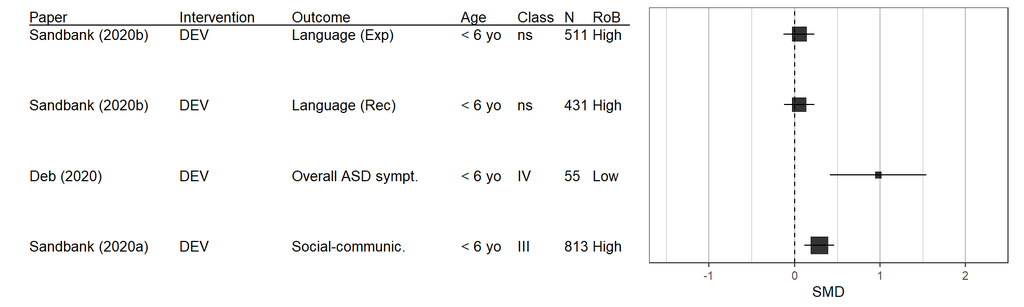

```r
res.dev <- res.main[which(grepl("DEV", res.main$Intervention)), display.cols]# , ]
res.dev <- res.dev[order(res.dev$Class, decreasing = FALSE),]
res.dev <- res.dev[order(res.dev$Outcome, decreasing = TRUE),]

tab.dev <- data.frame(
  Paper = res.dev$Paper,
  Intervention = res.dev$Intervention,
  Outcome = res.dev$Outcome,
  Age = res.dev$Age,
  Class = res.dev$Class,
  N = res.dev$total_n,
  RoB = res.dev$'Risk of bias')

forest_modif(x = res.dev[, c("value", "se")],
           variant = "classic",
           col = "Greys", xlab = "SMD", annotate_CI = FALSE,
           study_table = tab.dev,
           group = tab.dev$Outcome,
           type = "study_only",
           text_size = 3.6,
           x_limit = c(-1.7, 2.5),
           N = res.dev$total_n,
           x_breaks = seq(-3, 3, 1))
```

#### Table

```r
DT::datatable(res.dev[, 1:24],
              rownames = FALSE,
              options = list(  # options
                scrollX = TRUE,
                dom = c('ft'),
                scrollY = "600px",
                pageLength = 600,
                order = list(3, 'asc'),
                autoWidth = TRUE,
                columnDefs = list(
                  list(width = '110px',
                       targets = "_all"),
                  list(className = 'dt-center',
                                     targets = "_all"))))
```

| Paper | Intervention | Intervention_precise | Outcome | Class | Sample size (studies) | Effect size | p_value | PI_eG | I2 | egger_p | ESB_p | largest_CI_eG | amstar | Risk of bias | Age | Age_bounds | IQ | Type of outcome | % of active controls | Intensity | Duration | Implementer | Setting |
| --- | --- | --- | --- | --- | --- | --- | --- | --- | --- | --- | --- | --- | --- | --- | --- | --- | --- | --- | --- | --- | --- | --- | --- |
| Sandbank (2020a) | DEV | DEV | Social-communic. | III | 813 (14) | SMD = 0.29 [0.118, 0.463] | 9.79e-04 | [-0.148, 0.728] | 28.702 | 6.68e-01 | 3.87e-02 | [-0.147, 0.468] | 3/5 | High | &lt; 6 yo | [1.8 - 7.4] | Limit (70-79) | Observation | 9% | 5-9 h/wk | 7-12 months | Caregiver | Home |
| Deb (2020) | DEV | DEV | Overall ASD sympt. | IV | 55 (2) | SMD = 0.98 [0.413, 1.546] | 6.96e-04 | &lt; 3 studies | 0 | &lt; 3 studies | 2.95e-01 | [0.034, 1.569] | 3/5 | Low | &lt; 6 yo | [4 - 4.5] | Low (&lt; 70) |  | 44% | 10-19 h/wk | 2-6 months | Caregiver | Home |
| Sandbank (2020b) | DEV | DEV | Language (Rec) | ns | 431 (7) | SMD = 0.055 [-0.124, 0.235] | 5.45e-01 | [-0.18, 0.291] | 0 | 5.08e-01 | 1.00e+00 | [-0.164, 0.445] | 3/5 | High | &lt; 6 yo | [1.8 - 5.4] | Low (&lt; 70) | Report | 0% | 2-4 h/wk | 7-12 months | Caregiver | Home |
| Sandbank (2020b) | DEV | DEV | Language (Exp) | ns | 511 (8) | SMD = 0.055 [-0.126, 0.236] | 5.51e-01 | [-0.171, 0.281] | 0 | 9.38e-01 | 1.00e+00 | [-0.277, 0.331] | 3/5 | High | &lt; 6 yo | [1.8 - 5.4] | Low (&lt; 70) | Report | 0% | 5-9 h/wk | 7-12 months | Caregiver | Home |

### 4. SSG

#### Plot

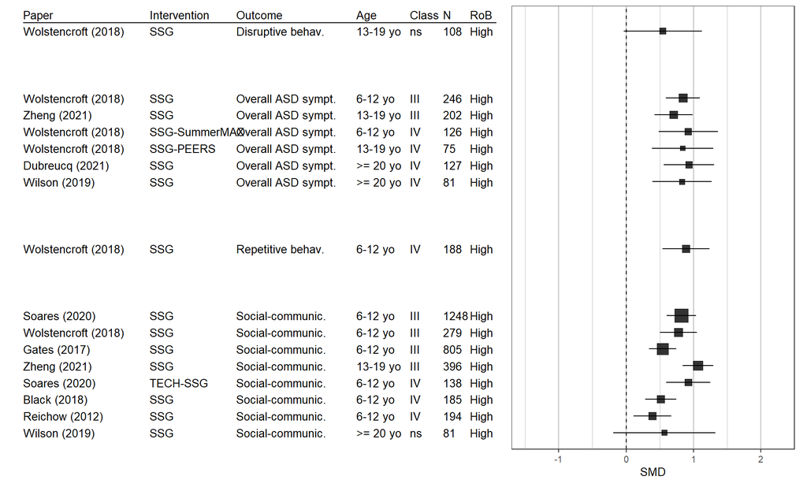

```r
res.ssg <- res.main[which(grepl("SSG", res.main$Intervention)), display.cols]# , ]
res.ssg <- res.ssg[order(res.ssg$Age, decreasing = TRUE),]
res.ssg <- res.ssg[order(res.ssg$Class, decreasing = FALSE),]
res.ssg <- res.ssg[order(res.ssg$Outcome, decreasing = TRUE),]

tab.ssg <- data.frame(
  Paper = res.ssg$Paper,
  Intervention = res.ssg$Intervention,
  Outcome = res.ssg$Outcome,
  Age = res.ssg$Age,
  Class = res.ssg$Class,
  N = res.ssg$total_n,
  RoB = res.ssg$'Risk of bias')

forest_modif(x = res.ssg[, c("value", "se")],
           variant = "classic",
           col = "Greys", xlab = "SMD", annotate_CI = FALSE,
           study_table = tab.ssg,
           group = tab.ssg$Outcome,
           type = "study_only",
           text_size = 3.6,
           x_limit = c(-1.7, 2.5),
           N = res.ssg$total_n,
           x_breaks = seq(-3, 3, 1))
```

#### Table

```r
DT::datatable(res.ssg[, 1:24],
              rownames = FALSE,
              options = list(  # options
                scrollX = TRUE,
                dom = c('ft'),
                scrollY = "600px",
                pageLength = 600,
                order = list(3, 'asc'),
                autoWidth = TRUE,
                columnDefs = list(
                  list(width = '110px',
                       targets = "_all"),
                  list(className = 'dt-center',
                                     targets = "_all"))))
```

| Paper | Intervention | Intervention_precise | Outcome | Class | Sample size (studies) | Effect size | p_value | PI_eG | I2 | egger_p | ESB_p | largest_CI_eG | amstar | Risk of bias | Age | Age_bounds | IQ | Type of outcome | % of active controls | Intensity | Duration | Implementer | Setting |
| --- | --- | --- | --- | --- | --- | --- | --- | --- | --- | --- | --- | --- | --- | --- | --- | --- | --- | --- | --- | --- | --- | --- | --- |
| Soares (2020) | SSG | SSG | Social-communic. | III | 1248 (18) | SMD = 0.819 [0.601, 1.037] | 1.84e-13 | [0.007, 1.63] | 71.628 | 3.01e-04 | 4.37e-10 | [-0.065, 0.385] | 2/5 | High | 6-12 yo | [7.5 - 15.2] | Average (80-119) | Report | 0% | 2-4 h/wk | 2-6 months | Profesionnal | Clinic |
| Wolstencroft (2018) | SSG | SSG | Social-communic. | III | 279 (8) | SMD = 0.776 [0.504, 1.048] | 2.24e-08 | [0.207, 1.344] | 9.624 | 7.10e-01 | 1.12e-01 | [-0.07, 0.97] | 3/5 | High | 6-12 yo | [9.2 - 20.4] | Average (80-119) | Report | 0% | 10-19 h/wk | 2-6 months | Profesionnal | Clinic |
| Gates (2017) | SSG | SSG | Social-communic. | III | 805 (19) | SMD = 0.542 [0.337, 0.746] | 2.07e-07 | [0.322, 0.762] | 0 | 1.84e-02 | 8.08e-01 | [-0.659, 1.156] | 2/5 | High | 6-12 yo | [5.3 - 20.4] | Average (80-119) | Report | 0% | 5-9 h/wk | 2-6 months | Profesionnal | Clinic |
| Zheng (2021) | SSG | SSG | Social-communic. | III | 396 (9) | SMD = 1.067 [0.838, 1.295] | 6.40e-20 | [0.582, 1.552] | 25.377 | 4.03e-02 | 6.11e-01 | [0.824, 1.796] | 4/5 | High | 13-19 yo | [12.7 - 15.2] | Average (80-119) | Report | 0% | &lt; 2 h/wk | 2-6 months | Profesionnal | Clinic |
| Soares (2020) | TECH-SSG | TECH-SSG | Social-communic. | IV | 138 (4) | SMD = 0.922 [0.594, 1.25] | 3.67e-08 | [0.201, 1.642] | 0 | 5.77e-01 | 9.10e-01 | [0.555, 1.75] | 2/5 | High | 6-12 yo | [7.5 - 10.1] | Average (80-119) | Report | 0% | &lt; 2 h/wk | 2-6 months | Profesionnal | School |
| Black (2018) | SSG | SSG | Social-communic. | IV | 185 (5) | SMD = 0.515 [0.284, 0.747] | 1.29e-05 | [0.139, 0.891] | 0 | 4.19e-01 | 8.80e-01 | [0.216, 0.985] | 2/5 | High | 6-12 yo | [8.5 - 14.6] | Average (80-119) |  | 0% | 10-19 h/wk | 2-6 months | Profesionnal | Clinic |
| Reichow (2012) | SSG | SSG | Social-communic. | IV | 194 (5) | SMD = 0.392 [0.11, 0.673] | 6.39e-03 | [-0.065, 0.849] | 0 | 8.47e-01 | 8.36e-01 | [-0.012, 0.971] | 5/5 | High | 6-12 yo | [8.6 - 14.6] | Average (80-119) | Report | 0% | 5-9 h/wk | 2-6 months | Profesionnal | Clinic |
| Wilson (2019) | SSG | SSG | Social-communic. | ns | 81 (3) | SMD = 0.568 [-0.189, 1.324] | 1.41e-01 | [-7.77, 8.906] | 60.689 | 6.06e-01 | 3.42e-01 | [-0.273, 0.875] | 2/5 | High | &gt;= 20 yo | [20.2 - 20.4] | Average (80-119) | Report | 0% | &lt; 2 h/wk | 2-6 months | Profesionnal | Clinic |
| Wolstencroft (2018) | SSG | SSG | Repetitive behav. | IV | 188 (6) | SMD = 0.889 [0.54, 1.238] | 5.86e-07 | [0.08, 1.698] | 17.837 | 4.92e-01 | 1.00e+00 | [0.84, 2] | 3/5 | High | 6-12 yo | [9.2 - 20.4] | Average (80-119) | Report | 0% | &gt;= 20h/wk | &lt; 2 months | Profesionnal | Clinic |
| Wolstencroft (2018) | SSG | SSG | Overall ASD sympt. | III | 246 (7) | SMD = 0.844 [0.591, 1.097] | 5.89e-11 | [0.513, 1.176] | 0 | 7.16e-02 | 7.15e-01 | [0.37, 1.45] | 3/5 | High | 6-12 yo | [9.2 - 20.4] | Average (80-119) | Report | 0% | 10-19 h/wk | 2-6 months | Profesionnal | Clinic |

[output cut: 6 more lines]

### 5. PMI

#### Plot

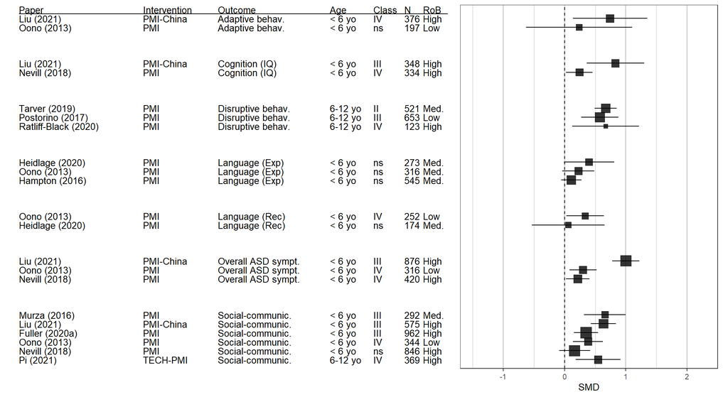

```r
res.pmi <- res.main[which(grepl("PMI", res.main$Intervention)), display.cols]# , ]
res.pmi <- res.pmi[order(res.pmi$Age, decreasing = FALSE),]
res.pmi <- res.pmi[order(res.pmi$Outcome, decreasing = TRUE),]

tab.pmi <- data.frame(
  Paper = res.pmi$Paper,
  Intervention = res.pmi$Intervention,
  Outcome = res.pmi$Outcome,
  Age = res.pmi$Age,
  Class = res.pmi$Class,
  N = res.pmi$total_n,
  RoB = res.pmi$'Risk of bias')

forest_modif(x = res.pmi[, c("value", "se")],
           variant = "classic",
           col = "Greys", xlab = "SMD", annotate_CI = FALSE,
           study_table = tab.pmi,
           group = tab.pmi$Outcome,
           type = "study_only",
           text_size = 3.6,
           x_limit = c(-1.7, 2.5),
           N = res.pmi$total_n,
           x_breaks = seq(-3, 3, 1))
```

#### Table

```r
DT::datatable(res.pmi[, 1:24],
              rownames = FALSE,
              options = list(  # options
                scrollX = TRUE,
                dom = c('ft'),
                scrollY = "600px",
                pageLength = 600,
                order = list(3, 'asc'),
                autoWidth = TRUE,
                columnDefs = list(
                  list(width = '110px',
                       targets = "_all"),
                  list(className = 'dt-center',
                                     targets = "_all"))))
```

| Paper | Intervention | Intervention_precise | Outcome | Class | Sample size (studies) | Effect size | p_value | PI_eG | I2 | egger_p | ESB_p | largest_CI_eG | amstar | Risk of bias | Age | Age_bounds | IQ | Type of outcome | % of active controls | Intensity | Duration | Implementer | Setting |
| --- | --- | --- | --- | --- | --- | --- | --- | --- | --- | --- | --- | --- | --- | --- | --- | --- | --- | --- | --- | --- | --- | --- | --- |
| Murza (2016) | PMI | PMI | Social-communic. | III | 292 (5) | SMD = 0.66 [0.32, 1] | 1.42e-04 | [-0.312, 1.632] | 44.157 | 8.52e-01 | 7.76e-01 | [0.392, 1.046] | 2.5/5 | Med. | &lt; 6 yo | [1.8 - 4.1] | Low (&lt; 70) | Observation | 0% | 2-4 h/wk | 7-12 months | Caregiver | Home |
| Liu (2021) | PMI-China | PMI-China | Social-communic. | III | 575 (6) | SMD = 0.635 [0.431, 0.839] | 1.09e-09 | [0.137, 1.133] | 29.024 | 4.60e-01 | 9.78e-01 | [0.44, 1.16] | 4/5 | High | &lt; 6 yo | [3.1 - 4.4] |  | Observation | 53% | &lt; 2 h/wk | 7-12 months | Caregiver |  |
| Fuller (2020a) | PMI | PMI | Social-communic. | III | 962 (19) | SMD = 0.35 [0.155, 0.546] | 4.54e-04 | [-0.354, 1.054] | 56.612 | 5.39e-01 | 2.98e-03 | [-0.175, 0.455] | 2/5 | High | &lt; 6 yo | [1.5 - 4.8] | Low (&lt; 70) | Observation | 18% | 2-4 h/wk | 7-12 months | Caregiver | Home |
| Oono (2013) | PMI | PMI | Social-communic. | IV | 344 (6) | SMD = 0.383 [0.139, 0.628] | 2.13e-03 | [-0.124, 0.891] | 24.243 | 1.31e-01 | 1.58e-01 | [-0.098, 0.503] | 5/5 | Low | &lt; 6 yo | [1.7 - 4.1] | Low (&lt; 70) | Observation | 0% | 5-9 h/wk | 7-12 months | Caregiver | Home |
| Nevill (2018) | PMI | PMI | Social-communic. | ns | 846 (13) | SMD = 0.164 [-0.09, 0.418] | 2.06e-01 | [-0.717, 1.046] | 66.577 | 1.17e-01 | 2.42e-01 | [0.058, 0.718] | 1/5 | High | &lt; 6 yo | [1.6 - 4.7] | Low (&lt; 70) | Report | 52% | 2-4 h/wk | 7-12 months | Caregiver | Home |
| Pi (2021) | TECH-PMI | TECH-PMI | Social-communic. | IV | 369 (8) | SMD = 0.548 [0.184, 0.912] | 3.16e-03 | [-0.575, 1.671] | 64.333 | 3.82e-02 | 4.48e-04 | [-0.393, 0.482] | 3/5 | High | 6-12 yo | [2.5 - 13] | Limit (70-79) | Report | 0% | &lt; 2 h/wk | 2-6 months | Profesionnal | Home |
| Liu (2021) | PMI-China | PMI-China | Overall ASD sympt. | III | 876 (11) | SMD = 1.001 [0.78, 1.221] | 6.16e-19 | [0.326, 1.675] | 60.322 | 6.77e-02 | 8.68e-01 | [0.82, 1.58] | 4/5 | High | &lt; 6 yo | [3.1 - 6.6] |  | Observation | 39% | 2-4 h/wk | 7-12 months | Caregiver | Home |
| Oono (2013) | PMI | PMI | Overall ASD sympt. | IV | 316 (6) | SMD = 0.301 [0.078, 0.523] | 8.08e-03 | [-0.014, 0.616] | 0 | 1.30e-01 | 5.11e-01 | [-0.119, 0.524] | 5/5 | Low | &lt; 6 yo | [1.9 - 4.5] | Low (&lt; 70) | Observation | 0% | 5-9 h/wk | 7-12 months | Caregiver | Home |
| Nevill (2018) | PMI | PMI | Overall ASD sympt. | IV | 420 (6) | SMD = 0.217 [0.025, 0.41] | 2.71e-02 | [-0.056, 0.49] | 0 | 1.49e-01 | 4.23e-01 | [-0.191, 0.464] | 1/5 | High | &lt; 6 yo | [1.6 - 4.1] | Low (&lt; 70) | Report | 31% | 2-4 h/wk | 7-12 months | Caregiver | Home |
| Oono (2013) | PMI | PMI | Language (Rec) | IV | 252 (4) | SMD = 0.337 [0.031, 0.643] | 3.07e-02 | [-0.603, 1.277] | 2.728 | 1.58e-01 | 3.06e-01 | [-0.164, 0.445] | 5/5 | Low | &lt; 6 yo | [1.9 - 4.1] | Low (&lt; 70) | Report | 0% | 5-9 h/wk | &gt; 12 months | Caregiver | Home |

[output cut: 11 more lines]

### 6. TECH

#### Plot

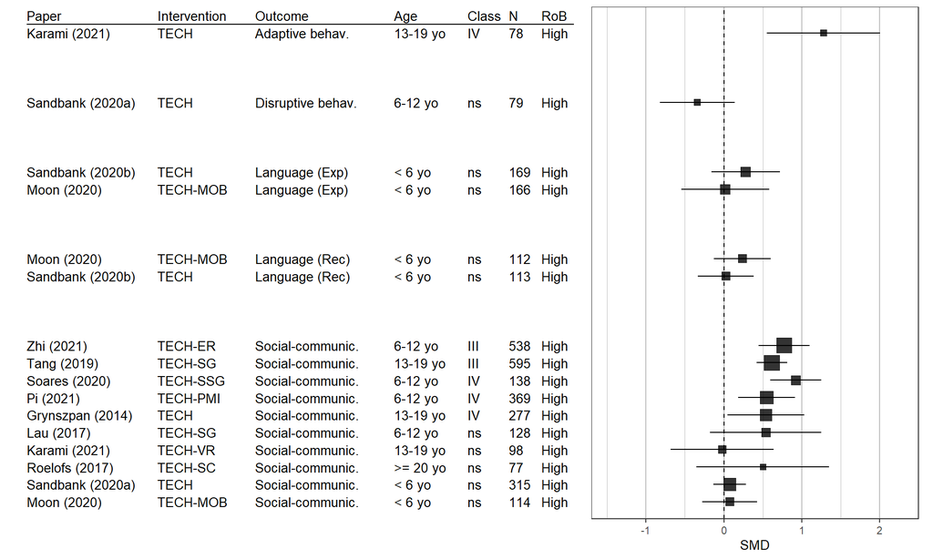

```r
res.tech <- res.main[which(grepl("TECH", res.main$Intervention_precise, fixed = TRUE)),
                           display.cols]# , ]
res.tech <- res.tech[order(res.tech$Age, decreasing = TRUE),]
res.tech <- res.tech[order(res.tech$Class, decreasing = FALSE),]
res.tech <- res.tech[order(res.tech$Outcome, decreasing = TRUE),]

tab.tech <- data.frame(
  Paper = res.tech$Paper,
  Intervention = res.tech$Intervention,
  Outcome = res.tech$Outcome,
  Age = paste0(res.tech$Age, " "),
  Class = res.tech$Class,
  N = paste0(round(res.tech$total_n), " "),
  RoB = res.tech$'Risk of bias')

forest_modif(x = res.tech[, c("value", "se")],
           variant = "classic",
           col = "Greys", xlab = "SMD", annotate_CI = FALSE,
           study_table = tab.tech,
           group = tab.tech$Outcome,
           type = "study_only",
           text_size = 3.6,
           x_limit = c(-1.7, 2.5),
           N = res.tech$total_n,
           x_breaks = seq(-3, 3, 1))
```

#### Table

```r
DT::datatable(res.tech[, 1:24],
              rownames = FALSE,
              options = list(  # options
                scrollX = TRUE,
                dom = c('ft'),
                scrollY = "600px",
                pageLength = 600,
                order = list(3, 'asc'),
                autoWidth = TRUE,
                columnDefs = list(
                  list(width = '110px',
                       targets = "_all"),
                  list(className = 'dt-center',
                                     targets = "_all"))))
```

| Paper | Intervention | Intervention_precise | Outcome | Class | Sample size (studies) | Effect size | p_value | PI_eG | I2 | egger_p | ESB_p | largest_CI_eG | amstar | Risk of bias | Age | Age_bounds | IQ | Type of outcome | % of active controls | Intensity | Duration | Implementer | Setting |
| --- | --- | --- | --- | --- | --- | --- | --- | --- | --- | --- | --- | --- | --- | --- | --- | --- | --- | --- | --- | --- | --- | --- | --- |
| Zhi (2021) | TECH-ER | TECH-ER | Social-communic. | III | 538 (14) | SMD = 0.773 [0.446, 1.1] | 3.58e-06 | [-0.339, 1.885] | 64.401 | 1.02e-03 | 2.73e-05 | [-0.646, 0.313] | 2/5 | High | 6-12 yo | [5.2 - 30.7] | Average (80-119) |  | 0% | 2-4 h/wk | &lt; 2 months | Profesionnal | School |
| Tang (2019) | TECH-SG | TECH-SG | Social-communic. | III | 595 (15) | SMD = 0.617 [0.422, 0.812] | 5.61e-10 | [0.012, 1.221] | 48.947 | 5.20e-03 | 2.15e-03 | [0.037, 0.608] | 2/5 | High | 13-19 yo | [4.1 - 30.7] | Average (80-119) | Test | 18% | &lt; 2 h/wk | 2-6 months | Profesionnal | Home |
| Soares (2020) | TECH-SSG | TECH-SSG | Social-communic. | IV | 138 (4) | SMD = 0.922 [0.594, 1.25] | 3.67e-08 | [0.201, 1.642] | 0 | 5.77e-01 | 9.10e-01 | [0.555, 1.75] | 2/5 | High | 6-12 yo | [7.5 - 10.1] | Average (80-119) | Report | 0% | &lt; 2 h/wk | 2-6 months | Profesionnal | School |
| Pi (2021) | TECH-PMI | TECH-PMI | Social-communic. | IV | 369 (8) | SMD = 0.548 [0.184, 0.912] | 3.16e-03 | [-0.575, 1.671] | 64.333 | 3.82e-02 | 4.48e-04 | [-0.393, 0.482] | 3/5 | High | 6-12 yo | [2.5 - 13] | Limit (70-79) | Report | 0% | &lt; 2 h/wk | 2-6 months | Profesionnal | Home |
| Grynszpan (2014) | TECH | TECH | Social-communic. | IV | 277 (8) | SMD = 0.54 [0.046, 1.034] | 3.23e-02 | [-0.917, 1.997] | 67.034 | 3.63e-01 | 7.99e-02 | [-0.558, 0.34] | 1/5 | High | 13-19 yo | [5.6 - 30.5] | Average (80-119) | Test | 12% | 2-4 h/wk | &lt; 2 months | Profesionnal | Home |
| Lau (2017) | TECH-SG | TECH-SG | Social-communic. | ns | 128 (2) | SMD = 0.537 [-0.177, 1.25] | 1.40e-01 | &lt; 3 studies | 74.029 | &lt; 3 studies | 2.40e-01 | [-0.238, 0.638] | 3.5/5 | High | 6-12 yo | [9.7 - 10.5] | Average (80-119) | Report | 0% | 2-4 h/wk | &lt; 2 months | Profesionnal | Home |
| Karami (2021) | TECH-VR | TECH-VR | Social-communic. | ns | 98 (2) | SMD = -0.021 [-0.684, 0.641] | 9.50e-01 | &lt; 3 studies | 58.049 | &lt; 3 studies | 1.00e+00 | [-0.731, 0.147] | 0/5 | High | 13-19 yo | [9 - 25] | Average (80-119) | Report | 0% | 2-4 h/wk | 2-6 months | Profesionnal | Clinic |
| Roelofs (2017) | TECH-SC | TECH-SC | Social-communic. | ns | 77 (2) | SMD = 0.5 [-0.352, 1.353] | 2.50e-01 | &lt; 3 studies | 40.049 | &lt; 3 studies | 1.00e+00 | [-0.259, 0.74] | 0/5 | High | &gt;= 20 yo | [25.5 - 30.7] | Average (80-119) | Test | 44% | 2-4 h/wk | 2-6 months | Profesionnal | Home |
| Sandbank (2020a) | TECH | TECH | Social-communic. | ns | 315 (9) | SMD = 0.075 [-0.135, 0.284] | 4.86e-01 | [-0.178, 0.328] | 0 | 1.78e-01 | 1.00e+00 | [-0.22, 0.767] | 3/5 | High | &lt; 6 yo | [3.3 - 7.8] | Average (80-119) | Report | 0% | &lt; 2 h/wk | 2-6 months | Profesionnal | Home |
| Moon (2020) | TECH-MOB | TECH-MOB | Social-communic. | ns | 114 (2) | SMD = 0.075 [-0.279, 0.428] | 6.79e-01 | &lt; 3 studies | 0 | &lt; 3 studies | 1.00e+00 | [-0.366, 0.684] | 3.5/5 | High | &lt; 6 yo | [3.3 - 4.2] |  | Observation | 0% | &lt; 2 h/wk | 2-6 months | Profesionnal | Home |

[output cut: 6 more lines]

### 7. CBT

#### Plot

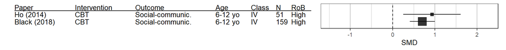

```r
res.cbt <- res.main[which(grepl("CBT", res.main$Intervention)), display.cols]# , ]
res.cbt <- res.cbt[order(res.cbt$Class, decreasing = FALSE),]
res.cbt <- res.cbt[order(res.cbt$Outcome, decreasing = TRUE),]

tab.cbt <- data.frame(
  Paper = res.cbt$Paper,
  Intervention = res.cbt$Intervention,
  Outcome = res.cbt$Outcome,
  Age = res.cbt$Age,
  Class = res.cbt$Class,
  N = res.cbt$total_n,
  RoB = res.cbt$'Risk of bias')

forest_modif(x = res.cbt[, c("value", "se")],
           variant = "classic",
           col = "Greys", xlab = "SMD", annotate_CI = FALSE,
           study_table = tab.cbt,
           group = tab.cbt$Outcome,
           type = "study_only",
           text_size = 3.6,
           x_limit = c(-1.7, 2.5),
           N = res.cbt$total_n,
           x_breaks = seq(-3, 3, 1))
```

#### Table

```r
DT::datatable(res.cbt[, 1:24],
              rownames = FALSE,
              options = list(  # options
                scrollX = TRUE,
                dom = c('ft'),
                scrollY = "600px",
                order = list(3, 'asc'),
                autoWidth = TRUE,
                columnDefs = list(
                  list(width = '110px',
                       targets = "_all"),
                  list(className = 'dt-center',
                                     targets = "_all"))))
```

| Paper | Intervention | Intervention_precise | Outcome | Class | Sample size (studies) | Effect size | p_value | PI_eG | I2 | egger_p | ESB_p | largest_CI_eG | amstar | Risk of bias | Age | Age_bounds | IQ | Type of outcome | % of active controls | Intensity | Duration | Implementer | Setting |
| --- | --- | --- | --- | --- | --- | --- | --- | --- | --- | --- | --- | --- | --- | --- | --- | --- | --- | --- | --- | --- | --- | --- | --- |
| Ho (2014) | CBT | CBT | Social-communic. | IV | 51 (2) | SMD = 0.932 [0.253, 1.61] | 7.16e-03 | &lt; 3 studies | 0 | &lt; 3 studies | 7.25e-01 | [0.013, 1.945] | 2/5 | High | 6-12 yo | [9.2 - 11.1] | Average (80-119) |  | 0% | &lt; 2 h/wk | 2-6 months | Profesionnal | Clinic |
| Black (2018) | CBT | CBT | Social-communic. | IV | 159 (5) | SMD = 0.704 [0.408, 1] | 3.21e-06 | [0.223, 1.185] | 0 | 2.38e-01 | 1.85e-01 | [0.099, 0.97] | 2/5 | High | 6-12 yo | [8.8 - 14.6] | Average (80-119) |  | 0% | &lt; 2 h/wk | 2-6 months | Profesionnal | Clinic |

### 8. TEACCH

#### Plot

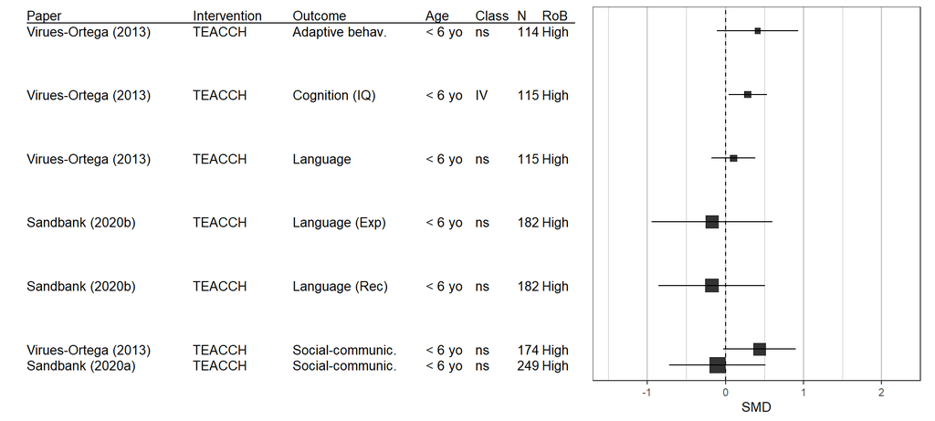

```r
res.teacch <- res.main[which(grepl("TEACCH", res.main$Intervention)), display.cols]# , ]
res.teacch <- res.teacch[order(res.teacch$Class, decreasing = FALSE),]
res.teacch <- res.teacch[order(res.teacch$Outcome, decreasing = TRUE),]

tab.teacch <- data.frame(
  Paper = res.teacch$Paper,
  Intervention = res.teacch$Intervention,
  Outcome = res.teacch$Outcome,
  Age = res.teacch$Age,
  Class = res.teacch$Class,
  N = res.teacch$total_n,
  RoB = res.teacch$'Risk of bias')

forest_modif(x = res.teacch[, c("value", "se")],
           variant = "classic",
           col = "Greys", xlab = "SMD", annotate_CI = FALSE,
           study_table = tab.teacch,
           group = tab.teacch$Outcome,
           type = "study_only",
           text_size = 3.6,
           x_limit = c(-1.7, 2.5),
           N = res.teacch$total_n,
           x_breaks = seq(-3, 3, 1))
```

#### Table

```r
DT::datatable(res.teacch[, 1:24],
              rownames = FALSE,
              options = list(  # options
                scrollX = TRUE,
                dom = c('ft'),
                order = list(3, 'asc'),
                autoWidth = TRUE,
                columnDefs = list(
                  list(width = '110px',
                       targets = "_all"),
                  list(className = 'dt-center',
                                     targets = "_all"))))
```

| Paper | Intervention | Intervention_precise | Outcome | Class | Sample size (studies) | Effect size | p_value | PI_eG | I2 | egger_p | ESB_p | largest_CI_eG | amstar | Risk of bias | Age | Age_bounds | IQ | Type of outcome | % of active controls | Intensity | Duration | Implementer | Setting |
| --- | --- | --- | --- | --- | --- | --- | --- | --- | --- | --- | --- | --- | --- | --- | --- | --- | --- | --- | --- | --- | --- | --- | --- |
| Virues-Ortega (2013) | TEACCH | TEACCH | Social-communic. | ns | 174 (6) | SMD = 0.438 [-0.027, 0.902] | 6.47e-02 | [-1.105, 1.98] | 78.175 | 4.61e-01 | 9.98e-01 | [0.434, 1.25] | 2/5 | High | &lt; 6 yo | [2.5 - 9.7] | Low (&lt; 70) | Report | 0% | 10-19 h/wk | 2-6 months | Profesionnal | Home |
| Sandbank (2020a) | TEACCH | TEACCH | Social-communic. | ns | 249 (6) | SMD = -0.105 [-0.723, 0.512] | 7.38e-01 | [-2.125, 1.914] | 72.995 | 6.87e-01 | 6.69e-01 | [-0.657, 0.015] | 3/5 | High | &lt; 6 yo | [2.5 - 5.3] | Low (&lt; 70) | Test | 0% | 10-19 h/wk | 7-12 months | Profesionnal | School |
| Sandbank (2020b) | TEACCH | TEACCH | Language (Rec) | ns | 182 (3) | SMD = -0.175 [-0.858, 0.508] | 6.15e-01 | [-8.01, 7.66] | 75.556 | 1.44e-01 | 9.39e-01 | [-1.079, -0.369] | 3/5 | High | &lt; 6 yo | [2.5 - 4.1] | Low (&lt; 70) | Test | 0% | 5-9 h/wk | 7-12 months | Profesionnal | School |
| Sandbank (2020b) | TEACCH | TEACCH | Language (Exp) | ns | 182 (3) | SMD = -0.172 [-0.948, 0.603] | 6.63e-01 | [-9.304, 8.959] | 81.212 | 2.18e-01 | 9.60e-01 | [-1.17, -0.447] | 3/5 | High | &lt; 6 yo | [2.5 - 4.1] | Low (&lt; 70) | Test | 0% | 5-9 h/wk | 7-12 months | Profesionnal | School |
| Virues-Ortega (2013) | TEACCH | TEACCH | Language | ns | 115 (5) | SMD = 0.103 [-0.178, 0.384] | 4.72e-01 | [-0.353, 0.56] | 0 | 7.06e-01 | 1.00e+00 | [-0.596, 0.494] | 2/5 | High | &lt; 6 yo | [2.5 - 9.7] | Low (&lt; 70) | Test | 0% | 10-19 h/wk | 2-6 months | Profesionnal | School |
| Virues-Ortega (2013) | TEACCH | TEACCH | Cognition (IQ) | IV | 115 (5) | SMD = 0.285 [0.037, 0.532] | 2.44e-02 | [-0.545, 1.114] | 67.595 | 6.30e-02 | 1.82e-03 | [-0.296, 0.206] | 2/5 | High | &lt; 6 yo | [2.5 - 9.7] | Low (&lt; 70) | Test | 0% | 10-19 h/wk | 2-6 months | Profesionnal | School |
| Virues-Ortega (2013) | TEACCH | TEACCH | Adaptive behav. | ns | 114 (3) | SMD = 0.412 [-0.108, 0.932] | 1.20e-01 | [-5.461, 6.285] | 69.89 | 9.13e-01 | 9.87e-01 | [0.301, 1.155] | 2/5 | High | &lt; 6 yo | [2.8 - 9.7] | Low (&lt; 70) | Report | 0% | 10-19 h/wk | 2-6 months | Profesionnal | Home |

## C. Precise outcomes

This last supplementary analysis present results of all meta-analyses taken independently (i.e., when a given paper reports several meta-analysis of the same intervention on the same outcome, we now present them individually)

```r
df_all <- df_raw
df_all$factor <- with(df_all, paste0(First_author_meta, "_", Year_meta,  "_", Intervention_precise, "_", Outcome_general, "_", Outcome_precise))

umb.all <- metaumbrella::umbrella(df_all, mult.level = TRUE, method.var = "REML", r = 0.8, verbose = FALSE)
res.transit.all <- metaumbrella::add.evidence(umb.all,
    criteria = "Personalized",
    class_I = c(total_n = 500, p_value = 1e-3, I2 = 50,
                egger_p = .05, pi = "notnull",
                rob = 75, amstar = 4.99),
    class_II = c(total_n = 350, p_value = 1e-3,
                largest_CI = "notnull",
                rob = 50, amstar = 3.99),
    class_III = c(total_n = 200, p_value = 1e-3),
    class_IV = c(p_value = 5e-2), verbose = FALSE)

res.all <- metaumbrella::summary.umbrella(res.transit.all)
res.all = gen_id_tot(res.all$Factor, res.all)
```

```r
# merge datasets
res.all$factor <- res.all$Factor
res.all.S2 <- dplyr::left_join(res.all, df_agg_meta)

# estimate the STANDARD ERROR of the pooled ES
ci_lo_transit <- ci_up_transit <- CI_up <- CI_lo <- NA
for (i in 1:nrow(res.all.S2)) {
    ci_lo_transit[i] <- gsub(",.*", "", res.all.S2$value_CI[i])
    ci_up_transit[i] <- gsub(".*, ", "", res.all.S2$value_CI[i])
    CI_lo[i] <- gsub("\\[", "", ci_lo_transit[i])
    CI_up[i] <- gsub("]", "", ci_up_transit[i])
}
CI_lo <- as.numeric(as.character(CI_lo))
CI_up <- as.numeric(as.character(CI_up))
res.all.S2$se <- (CI_up - CI_lo) / 3.92

# Create/recode some variables
res.all.S2$total_n <- round(res.all.S2$total_n)
res.all.S2$Class <- ifelse(res.all.S2$Class == "V", "ns", as.character(res.all.S2$Class))
res.all.S2$Sample_size_studies <- with(res.all.S2, paste0(total_n, " (", n_studies, ")"))
res.all.S2$Effect_size <- paste0("SMD = ", res.all.S2$value, " [", CI_lo, ", ", CI_up, "]")
res.all.S2$Risk_of_bias <- with(res.all.S2, ifelse(rob < 50, "High",
                                               ifelse(rob < 75, "Med.", ifelse(rob >= 75, "Low", NA_real_))))
res.all.S2$Active_controls <- paste0(round(res.all.S2$Active_controls), "%")
```

### Table

```r
colnames(res.all.S2)[colnames(res.all.S2) == "Effect_size"] <- "Effect size"
colnames(res.all.S2)[colnames(res.all.S2) == "Sample_size_studies"] <- "Sample size (studies)"
colnames(res.all.S2)[colnames(res.all.S2) == "Type_of_outcome"] <- "Type of outcome"
colnames(res.all.S2)[colnames(res.all.S2) == "Active_controls"] <- "% of active controls"
colnames(res.all.S2)[colnames(res.all.S2) == "Risk_of_bias"] <- "Risk of bias"

res.all.S2$Outcome <- rename_outcome(res.all.S2$Outcome)


res.all.S2 <- res.all.S2[order(res.all.S2$Outcome,res.all.S2$Class, res.all.S2$Age, decreasing = FALSE),]
res.all.S2 <- res.all.S2[order(res.all.S2$Age),]

res.all.S2$Age <- factor(res.all.S2$Age, levels = c("< 6 yo", "6-12 yo", "13-19 yo", ">= 20 yo"))
res.all.S2$Class <- factor(res.all.S2$Class, levels = c("I", "II", "III", "IV", "ns"))

DT::datatable(res.all.S2[,1:34],
              rownames = FALSE,
              options = list(  # options
                scrollX = TRUE,
                dom = c('ft'),
                scrollY = "600px",
                pageLength = 600,
                order = list(3, 'asc'),
                autoWidth = TRUE,
                columnDefs = list(
                  list(width = '110px',
                       targets = "_all"),
                  list(className = 'dt-center',
                                     targets = "_all"))))
```

| Author | Year | Intervention | Outcome | Outcome_precise | Factor | Criteria | Class | measure | value | value_CI | eG | eG_CI | eOR | eOR_CI | p_value | n_studies | total_n | n_cases | PI_eG | PI_eOR | PI_sign | I2 | egger_p | ESB_p | largest_CI_eG | largest_CI_eOR | largest_sign | JK_p | JK_sign | … |
| --- | --- | --- | --- | --- | --- | --- | --- | --- | --- | --- | --- | --- | --- | --- | --- | --- | --- | --- | --- | --- | --- | --- | --- | --- | --- | --- | --- | --- | --- | --- |
| Peters-Scheffer | 2011 | EIBI | Adaptive behav. | NA | Peters-Scheffer_2011_EIBI_Adaptive behaviors_NA | Personalized | III | G | 0.843 | [0.432, 1.254] | 0.843 | [0.432, 1.254] | 4.615 | [2.189, 9.728] | 5.84e-05 | 6 | 220 | 99 | [-0.3, 1.987] | [0.58, 36.719] | null | 47.881 | 2.17e-01 | 1.00e+00 | [0.913, 2.186] | [5.238, 52.69] | notnull | 1.64e-03 | n.s. | … |
| Virues-Ortega | 2010 | EIBI | Adaptive behav. | NA | Virues-Ortega_2010_EIBI_Adaptive behaviors_NA | Personalized | III | G | 0.791 | [0.323, 1.259] | 0.791 | [0.323, 1.259] | 4.198 | [1.795, 9.817] | 9.32e-04 | 7 | 238 | 135 | [-0.575, 2.157] | [0.352, 50.003] | null | 57.25 | 8.33e-01 | 7.69e-02 | [-0.018, 1.294] | [0.969, 10.459] | null | 1.30e-02 | n.s. | … |
| Reichow | 2018 | EIBI | Adaptive behav. | NA | Reichow_2018_EIBI_Adaptive behaviors_NA | Personalized | III | G | 0.627 | [0.339, 0.915] | 0.627 | [0.339, 0.915] | 3.12 | [1.851, 5.261] | 1.95e-05 | 5 | 202 | 107 | [0.16, 1.095] | [1.336, 7.287] | notnull | 0 | 1.37e-01 | 9.56e-01 | [0.308, 1.564] | [1.749, 17.059] | notnull | 1.21e-03 | n.s. | … |
| Rodgers | 2021 | EIBI | Adaptive behav. | NA | Rodgers_2021_EIBI_Adaptive behaviors_NA | Personalized | III | G | 0.566 | [0.294, 0.838] | 0.566 | [0.294, 0.838] | 2.792 | [1.704, 4.574] | 4.60e-05 | 10 | 396 | 244 | [-0.078, 1.211] | [0.867, 8.986] | null | 45.069 | 1.20e-01 | 2.39e-03 | [-0.209, 0.689] | [0.684, 3.489] | null | 5.35e-04 | n.s. | … |
| Karami | 2021 | TECH | Adaptive behav. | NA | Karami_2021_TECH_Adaptive behaviors_NA | Personalized | IV | G | 1.279 | [0.552, 2.006] | 1.279 | [0.552, 2.006] | 10.178 | [2.723, 38.047] | 5.63e-04 | 2 | 78 | 44 | &lt; 3 studies | &lt; 3 studies |  | 38.669 | &lt; 3 studies | 4.62e-01 | [0.439, 1.601] | [2.216, 18.259] | notnull | 9.26e-04 | n.s. | … |
| Liu | 2021 | PMI-China | Adaptive behav. | NA | Liu_2021_PMI-China_Adaptive behaviors_NA | Personalized | IV | G | 0.744 | [0.138, 1.349] | 0.744 | [0.138, 1.349] | 3.854 | [1.285, 11.561] | 1.61e-02 | 4 | 376 | 188 | [-2.017, 3.504] | [0.026, 575.928] | null | 75.778 | 1.33e-01 | 4.57e-01 | [0.11, 0.81] | [1.221, 4.346] | notnull | 9.38e-02 | n.s. | … |
| Eldevik | 2009 | EIBI | Adaptive behav. | NA | Eldevik_2009_EIBI_Adaptive behaviors_NA | Personalized | IV | G | 0.642 | [0.274, 1.01] | 0.642 | [0.274, 1.01] | 3.205 | [1.643, 6.252] | 6.32e-04 | 6 | 188 | 110 | [-0.237, 1.522] | [0.65, 15.804] | null | 29.288 | 3.31e-01 | 7.55e-01 | [0.213, 1.457] | [1.472, 14.045] | notnull | 1.37e-02 | n.s. | … |
| Shi | 2021 | EIBI | Adaptive behav. | NA | Shi_2021_EIBI_Adaptive behaviors_NA | Personalized | IV | G | 0.467 | [0.119, 0.816] | 0.467 | [0.119, 0.816] | 2.334 | [1.24, 4.393] | 8.64e-03 | 5 | 178 | 101 | [-0.381, 1.316] | [0.501, 10.881] | null | 28.235 | 8.19e-01 | 9.99e-01 | [0.36, 1.84] | [1.921, 28.146] | notnull | 7.65e-02 | n.s. | … |
| Makrygianni | 2010 | EIBI | Adaptive behav. | NA | Makrygianni_2010_EIBI_Adaptive behaviors_NA | Personalized | ns | G | 0.815 | [-0.032, 1.661] | 0.815 | [-0.032, 1.661] | 4.384 | [0.944, 20.357] | 5.92e-02 | 3 | 119 | 62 | [-9.287, 10.917] | [0, 397502064.035] | null | 78.844 | 5.22e-01 | 9.65e-01 | [0.464, 1.746] | [2.32, 23.731] | notnull | 3.55e-01 | n.s. | … |
| Virues-Ortega | 2013 | TEACCH | Adaptive behav. | VABS-composite | Virues-Ortega_2013_TEACCH_Adaptive behaviors_VABS-composite | Personalized | ns | G | 0.412 | [-0.108, 0.932] | 0.412 | [-0.108, 0.932] | 2.111 | [0.822, 5.419] | 1.20e-01 | 3 | 114 | 62 | [-5.461, 6.285] | [0, 89316.514] | null | 69.89 | 9.13e-01 | 9.87e-01 | [0.301, 1.155] | [1.726, 8.13] | notnull | 5.13e-01 | n.s. | … |

[output cut: 151 more lines]

# S3. Exploratory analysis

This unplanned exploratory analysis aims to limit the inclusion of the same trials in different meta-analysis. More precisely, we assessed the efficacy of each intervention type on each outcome but including all trials identified by all the meta-analyses. To avoid inclusion of the same trial multiple times, we separated the results for each age group using the mean age of the sample in each trial.

## Data analysis

```r
for (fact in unique(df_raw_S3$factor)) {
  i = which(df_raw_S3$factor == fact)
  df_raw_S3$amstar[i] = min(df_raw_S3[i, ]$amstar)
}

errors <- metaumbrella::view.errors.umbrella(df_raw_S3, return = "data")

df_raw_S3[df_raw_S3$row_id %in% errors[errors$column_type_errors == "ERROR", ]$row_id , ]$multiple_es = "outcomes"
errors2 <- metaumbrella::view.errors.umbrella(df_raw_S3, return = "data")
umb.tot1 <- metaumbrella::umbrella(df_raw_S3,
                                   mult.level = TRUE, method.var = "REML",
                                   r = 0.8, verbose = FALSE)

strat.tot = metaumbrella::summary.umbrella(metaumbrella::add.evidence(umb.tot1,
                                            criteria = "Personalized",
                                            class_I = c(total_n = 500, p_value = 1e-3,
                                                        I2 = 50, pi = "notnull",
                                                        egger_p = .05,
                                                        rob = 75),
                                            class_II = c(total_n = 350, p_value = 1e-3,
                                                        largest_CI = "notnull",
                                                        rob = 50),
                                            class_III = c(total_n = 200, p_value = 1e-3),
                                            class_IV = c(p_value = 5e-2), verbose = FALSE))

strat.tot = subset(strat.tot, n_studies > 1)
res.S3 = gen_id_all(strat.tot$Factor, strat.tot)
```

```r
# merge datasets
res.S3$factor = res.S3$Factor
res.main.S3 <- dplyr::left_join(res.S3, df_agg_meta_S3)

# estimate the STANDARD ERROR of the pooled ES
ci_lo_transit <- ci_up_transit <- CI_up <- CI_lo <- NA
for (i in 1:nrow(res.main.S3)) {
    ci_lo_transit[i] <- gsub(",.*", "", res.main.S3$value_CI[i])
    ci_up_transit[i] <- gsub(".*, ", "", res.main.S3$value_CI[i])
    CI_lo[i] <- gsub("\\[", "", ci_lo_transit[i])
    CI_up[i] <- gsub("]", "", ci_up_transit[i])
}
CI_lo <- as.numeric(as.character(CI_lo))
CI_up <- as.numeric(as.character(CI_up))
res.main.S3$se <- (CI_up - CI_lo) / 3.92

# Create/recode some variables
res.main.S3$total_n <- round(res.main.S3$total_n)
res.main.S3$Class <- ifelse(res.main.S3$Class == "V", "ns", as.character(res.main.S3$Class))
res.main.S3$Sample_size_studies <- with(res.main.S3, paste0(total_n, " (", n_studies, ")"))
res.main.S3$Effect_size <- paste0("SMD = ", res.main.S3$value, " [", CI_lo, ", ", CI_up, "]")
res.main.S3$Risk_of_bias <- with(res.main.S3, ifelse(rob < 50, "High",
                                               ifelse(rob < 75, "Med.", ifelse(rob >= 75, "Low", NA_real_))))
res.main.S3$Active_controls <- paste0(round(res.main.S3$Active_controls), "%")

# Identify main characteristics (setting, outcome type, therapy implementer)
res.main.S3 = main_characteristics(res.main.S3)
```

### Plot

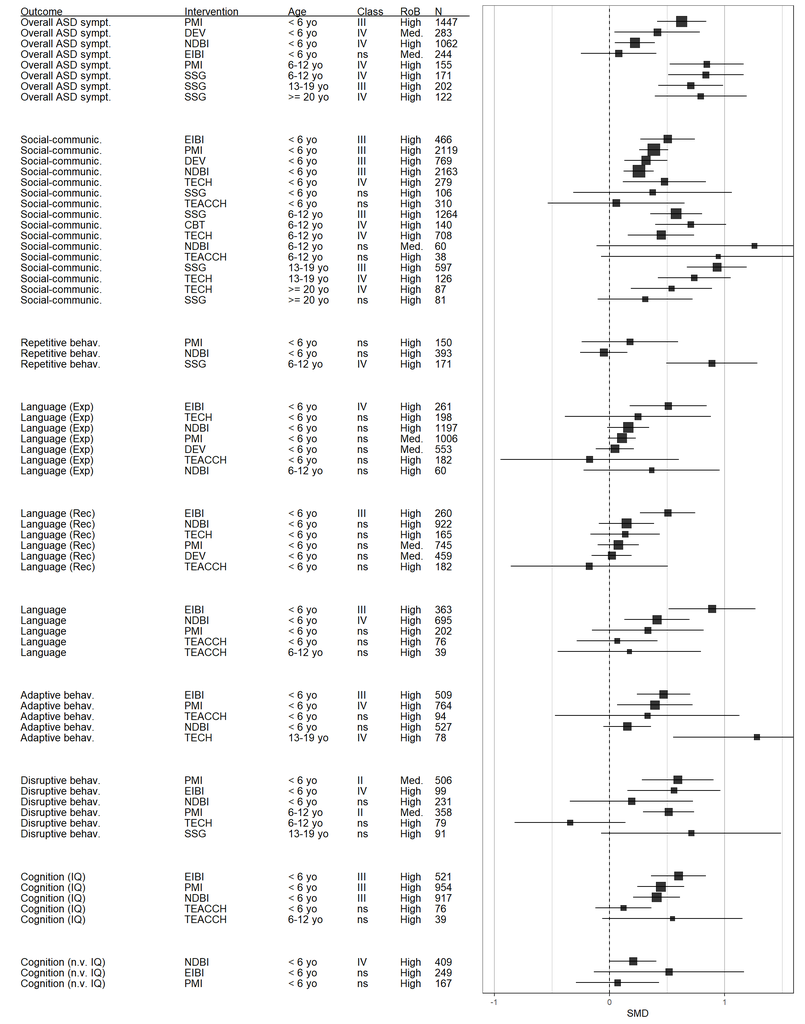

```r
res.S3.sub <- subset(res.main.S3, n_studies >= 2)
colnames(res.S3.sub)[colnames(res.S3.sub) == "Effect_size"] <- "Effect size"
colnames(res.S3.sub)[colnames(res.S3.sub) == "Sample_size_studies"] <- "Sample size (studies)"
colnames(res.S3.sub)[colnames(res.S3.sub) == "Type_of_outcome"] <- "Type of outcome"
colnames(res.S3.sub)[colnames(res.S3.sub) == "Active_controls"] <- "% of active controls"
colnames(res.S3.sub)[colnames(res.S3.sub) == "Risk_of_bias"] <- "Risk of bias"

res.S3.sub$Outcome <- rename_outcome(res.S3.sub$Outcome)

res.S3.2 <- res.S3.sub[, display.cols.all]

res.S3.2$Age <- factor(res.S3.2$Age, levels = c("< 6 yo", "6-12 yo", "13-19 yo", ">= 20 yo"))
res.S3.2$Class <- factor(res.S3.2$Class, levels = c("I", "II", "III", "IV", "ns"))
res.S3.2$Outcome <- factor(res.S3.2$Outcome,
                                levels = c("Overall ASD sympt.",
                                           "Social-communic.",
                                           "Repetitive behav.",
                                           "Language (Exp)",
                                           "Language (Rec)",
                                           "Language",
                                           "Adaptive behav.",
                                           "Disruptive behav.",
                                           "Cognition (IQ)",
                                           "Cognition (n.v. IQ)"))
res.S3.2 <- res.S3.2[order(res.S3.2$Outcome,res.S3.2$Class, res.S3.2$Age, decreasing = FALSE),]
res.S3.2 <- res.S3.2[order(res.S3.2$Age),]



tab.S3 <- data.frame(
  Outcome = res.S3.2$Outcome,
  Intervention = res.S3.2$Intervention,
  Age = res.S3.2$Age,
  Class = res.S3.2$Class,
  RoB = res.S3.2$'Risk of bias',
  N = round(res.S3.2$total_n))

forest_modif(x = res.S3.2[, c("value", "se")],
           variant = "classic",
           col = "Greys", xlab = "SMD", annotate_CI = F,
           study_table = tab.S3,
           group = tab.S3$Outcome,
           type = "study_only",
           text_size = 3.5,
           x_limit = c(-1.1, 1.6),
           N = res.S3.2$total_n,
           x_breaks = seq(-3, 3, 1))
```

### Table

```r
DT::datatable(res.S3.2,
              rownames = FALSE,
              options = list(  # options
                scrollX = TRUE,
                dom = c('ft'),
                scrollY = "600px",
                pageLength = 600,
                order = list(0, 'asc'),
                autoWidth = TRUE,
                columnDefs = list(
                  list(width = '110px',
                       targets = "_all"),
                  list(visible = FALSE,
                       targets = c(22:24)),
                  list(className = 'dt-center',
                                     targets = "_all"))))
```

| Intervention | Outcome | Age | Class | Sample size (studies) | Effect size | p_value | PI_eG | I2 | egger_p | ESB_p | largest_CI_eG | Risk of bias | Age.1 | Age_bounds | IQ | Type of outcome | % of active controls | Intensity | Duration | Implementer | Setting | total_n | value | se |
| --- | --- | --- | --- | --- | --- | --- | --- | --- | --- | --- | --- | --- | --- | --- | --- | --- | --- | --- | --- | --- | --- | --- | --- | --- |
| PMI | Overall ASD sympt. | &lt; 6 yo | III | 1447 (22) | SMD = 0.627 [0.414, 0.84] | 8.05e-09 | [-0.283, 1.538] | 73.22 | 3.41e-01 | 1.86e-05 | [-0.119, 0.524] | High | &lt; 6 yo | [1.6 - 5.8] | Low (&lt; 70) | Observation | 32% | 2-4 h/wk | 7-12 months | Caregiver | Home | 1447 | 0.627 | 0.108673469387755 |
| DEV | Overall ASD sympt. | &lt; 6 yo | IV | 283 (5) | SMD = 0.415 [0.044, 0.785] | 2.83e-02 | [-0.667, 1.497] | 46.585 | 1.84e-01 | 1.08e-01 | [-0.119, 0.524] | Med. | &lt; 6 yo | [1.8 - 4.5] | Low (&lt; 70) | Observation | 8% | 5-9 h/wk | 7-12 months | Caregiver | Home | 283 | 0.415 | 0.189030612244898 |
| NDBI | Overall ASD sympt. | &lt; 6 yo | IV | 1062 (21) | SMD = 0.221 [0.048, 0.393] | 1.24e-02 | [-0.374, 0.815] | 48.62 | 3.36e-01 | 4.65e-01 | [-0.575, 0.139] | High | &lt; 6 yo | [0.8 - 5.8] | Low (&lt; 70) | Observation | 15% | 10-19 h/wk | 7-12 months | Profesionnal | Home | 1062 | 0.221 | 0.0880102040816327 |
| EIBI | Overall ASD sympt. | &lt; 6 yo | ns | 244 (4) | SMD = 0.08 [-0.247, 0.406] | 6.33e-01 | [-1.024, 1.183] | 27.129 | 4.02e-02 | 1.00e+00 | [-0.575, 0.139] | Med. | &lt; 6 yo | [1.7 - 3.3] | Low (&lt; 70) | Observation | 0% | &gt;= 20h/wk | &gt; 12 months | Profesionnal | Home | 244 | 0.08 | 0.166581632653061 |
| EIBI | Social-communic. | &lt; 6 yo | III | 466 (10) | SMD = 0.506 [0.27, 0.742] | 2.63e-05 | [-0.072, 1.084] | 44.21 | 8.63e-02 | 7.61e-04 | [-0.199, 0.529] | High | &lt; 6 yo | [1.7 - 5.5] | Low (&lt; 70) | Report | 5% | &gt;= 20h/wk | &gt; 12 months | Profesionnal | Home | 466 | 0.506 | 0.120408163265306 |
| PMI | Social-communic. | &lt; 6 yo | III | 2119 (36) | SMD = 0.385 [0.26, 0.51] | 1.48e-09 | [-0.157, 0.927] | 48.788 | 7.64e-01 | 3.68e-05 | [-0.098, 0.503] | High | &lt; 6 yo | [1.5 - 4.8] | Low (&lt; 70) | Observation | 37% | 2-4 h/wk | 7-12 months | Caregiver | Home | 2119 | 0.385 | 0.0637755102040816 |
| DEV | Social-communic. | &lt; 6 yo | III | 769 (13) | SMD = 0.316 [0.129, 0.502] | 9.03e-04 | [-0.162, 0.794] | 34.639 | 6.29e-01 | 6.72e-02 | [-0.098, 0.503] | High | &lt; 6 yo | [1.7 - 5.4] | Limit (70-79) | Observation | 10% | 5-9 h/wk | 7-12 months | Caregiver | Home | 769 | 0.316 | 0.0951530612244898 |
| NDBI | Social-communic. | &lt; 6 yo | III | 2163 (41) | SMD = 0.254 [0.125, 0.384] | 1.20e-04 | [-0.372, 0.88] | 55.656 | 1.87e-01 | 3.59e-03 | [-0.209, 0.391] | High | &lt; 6 yo | [1.5 - 5.8] | Low (&lt; 70) | Observation | 20% | 5-9 h/wk | 7-12 months | Profesionnal | Home | 2163 | 0.254 | 0.0660714285714286 |
| TECH | Social-communic. | &lt; 6 yo | IV | 279 (6) | SMD = 0.477 [0.116, 0.837] | 9.53e-03 | [-0.567, 1.52] | 53.884 | 9.43e-02 | 8.15e-02 | [-0.366, 0.684] | High | &lt; 6 yo | [2.5 - 5.6] | Average (80-119) | Observation | 0% | 2-4 h/wk | 2-6 months | Profesionnal | Home | 279 | 0.477 | 0.183928571428571 |
| SSG | Social-communic. | &lt; 6 yo | ns | 106 (2) | SMD = 0.375 [-0.314, 1.063] | 2.86e-01 | &lt; 3 studies | 0 | &lt; 3 studies | 1.00e+00 | [-0.333, 1.379] | High | &lt; 6 yo | [5.3 - 5.8] | Average (80-119) | Report | 0% | &lt; 2 h/wk | 2-6 months | Profesionnal | Clinic | 106 | 0.375 | 0.351275510204082 |

[output cut: 54 more lines]

### Synthesis

Pooled ES

```r
synt.S3 = res.S3
synt.S3$ES_comb = paste(synt.S3$value, " ", synt.S3$value_CI)
synt.S3.ES = synt.S3[,c("Intervention", "Outcome", "ES_comb", "Age")] %>%
                  tidyr::pivot_wider(names_from = Outcome, values_from = ES_comb)


synt.S3.ES$Age <- ordered(synt.S3.ES$Age, levels = c("< 6 yo", "6-12 yo", "13-19 yo", ">= 20 yo"))
synt.S3.ES <- synt.S3.ES[order(synt.S3.ES$Intervention, synt.S3.ES$Age), ]
synt.S3.ES$Intervention = paste0(synt.S3.ES$Intervention, " (", synt.S3.ES$Age, ")")
# res.prim$Class <- factor(res.prim$Class, levels = c("I", "II", "III", "IV", "ns"))
# arrange(synt.S3.ES, Intervention, Age)

synt.S3.ES[is.na(synt.S3.ES)] <- "Not assessed"
DT::datatable(synt.S3.ES,
              rownames = FALSE,
              options = list(  # options
                scrollX = TRUE,
                order = list(1, 'asc'),
                pageLength = 1600,
                dom = c('t'),
                autoWidth = TRUE,
                columnDefs = list(
                  list(visible = FALSE,
                       targets = 1),
                  list(width = '150px',
                       targets = "_all"),
                  list(className = 'dt-center',
                                     targets = "_all"))))
```

| Intervention | Age | Disruptive behaviors | Social communication | Language | Overall ASD symptoms | Cognition(IQ) | Language(Receptive) | Adaptive behaviors | Restricted repetitive behaviors | Language(Expressive) | Cognition(nonverbal IQ) |
| --- | --- | --- | --- | --- | --- | --- | --- | --- | --- | --- | --- |
| CBT (6-12 yo) | 6-12 yo | Not assessed | 0.706 [0.398, 1.013] | Not assessed | Not assessed | Not assessed | Not assessed | Not assessed | Not assessed | Not assessed | Not assessed |
| DEV (&lt; 6 yo) | &lt; 6 yo | Not assessed | 0.316 [0.129, 0.502] | Not assessed | 0.415 [0.044, 0.785] | Not assessed | 0.02 [-0.153, 0.194] | Not assessed | Not assessed | 0.047 [-0.118, 0.211] | Not assessed |
| EIBI (&lt; 6 yo) | &lt; 6 yo | 0.56 [0.157, 0.962] | 0.506 [0.27, 0.742] | 0.89 [0.512, 1.267] | 0.08 [-0.247, 0.406] | 0.599 [0.36, 0.837] | 0.506 [0.266, 0.747] | 0.47 [0.238, 0.703] | Not assessed | 0.51 [0.176, 0.843] | 0.517 [-0.137, 1.17] |
| NDBI (&lt; 6 yo) | &lt; 6 yo | 0.192 [-0.343, 0.726] | 0.254 [0.125, 0.384] | 0.413 [0.131, 0.696] | 0.221 [0.048, 0.393] | 0.409 [0.205, 0.613] | 0.148 [-0.093, 0.388] | 0.155 [-0.051, 0.361] | -0.049 [-0.254, 0.156] | 0.163 [-0.019, 0.344] | 0.206 [0.004, 0.408] |
| NDBI (6-12 yo) | 6-12 yo | Not assessed | 1.257 [-0.111, 2.624] | Not assessed | Not assessed | Not assessed | Not assessed | Not assessed | Not assessed | 0.366 [-0.226, 0.958] | Not assessed |
| PMI (&lt; 6 yo) | &lt; 6 yo | 0.593 [0.281, 0.905] | 0.385 [0.26, 0.51] | 0.333 [-0.15, 0.817] | 0.627 [0.414, 0.84] | 0.447 [0.244, 0.651] | 0.077 [-0.103, 0.257] | 0.394 [0.068, 0.721] | 0.177 [-0.241, 0.596] | 0.108 [-0.014, 0.23] | 0.07 [-0.29, 0.43] |
| PMI (6-12 yo) | 6-12 yo | 0.514 [0.293, 0.736] | Not assessed | Not assessed | 0.845 [0.523, 1.167] | Not assessed | Not assessed | Not assessed | Not assessed | Not assessed | Not assessed |
| SSG (&lt; 6 yo) | &lt; 6 yo | Not assessed | 0.375 [-0.314, 1.063] | Not assessed | Not assessed | Not assessed | Not assessed | Not assessed | Not assessed | Not assessed | Not assessed |
| SSG (6-12 yo) | 6-12 yo | Not assessed | 0.579 [0.354, 0.804] | Not assessed | 0.837 [0.509, 1.165] | Not assessed | Not assessed | Not assessed | 0.888 [0.492, 1.283] | Not assessed | Not assessed |
| SSG (13-19 yo) | 13-19 yo | 0.709 [-0.071, 1.489] | 0.933 [0.673, 1.193] | Not assessed | 0.705 [0.423, 0.987] | Not assessed | Not assessed | Not assessed | Not assessed | Not assessed | Not assessed |

[output cut: 7 more lines]